# GATA3 PB-seq analysis

2026-04-16

# 1 PB-seq experiments

PB-seq measures protein abundance on naked DNA (in vitro asssay).

# 2 PB-seq experiments design

Naked genomic DNA (purified human gDNA) sheared to desired sizes, and incubated with purified GATA3 protein or mock (no protein), each with 4 replicates.

# 3 PB-seq data processing

## 3.1 Convert/Rename Data

**Converting data form**

```bash
# make sure there is a SampleSheet.csv in the *_AH57FJBGYX directory
# cd PBseq/260407_NB551647_0123_AH57FJBGYX
module load bcl2fastq
nohup bcl2fastq --runfolder-dir ./ --output-dir ./Data/Intensities/BaseCalls/ --no-lane-splitting
```

**Renaming file** We want to name the experiments with the trailing name being `PE1` or `PE2` for paired end data.

```bash
#cd /home/FCAM/ssun/PBseq/260407_NB551647_0123_AH57FJBGYX/Data/Intensities/BaseCalls
for i in PB*_S*R1_001.fastq.gz
do
    nm=$(echo $i | awk -F"/" '{print $NF}' | awk -F"_S" '{print $1}')
    echo $nm
    two=$(echo $i | awk -F"/" '{print $NF}' | awk -F"R1_001.fastq.gz" '{print $1}')
    mv $i ${nm}_PE1.fastq.gz
    mv ${two}R2_001.fastq.gz ${nm}_PE2.fastq.gz
done
```

## 3.2 check fastq file quality with `fastqc`

```bash
module load fastqc

for i in *fastq.gz
do
  echo $i
  fastqc $i
done
```

## 3.3 Cut off the adapter with `cutadapt`

In our daily workflow in the lab we use `cutadapt` to remove adapter sequences. The options we use below are:

- `-j` for the number of cores to use
- `-m` specifies the minimal length of a read to keep after adapter sequence removal
- `-O` is the number of bases to trim off the end of the read if it overlaps with the adapter sequence
- `-a` adapter sequence of PE1 reads
- `-A` adapter sequence of PE2 reads
- `-o` PE1 output file
- `-p` PE2 output file

If the genome contains 25% of each base, then you would expect one quarter of the reads that have no adapter to have the trailing base trimmed. Likewise, approximately 1/16 of the remaining reads without the adapter will have the final two bases trimmed. Technically these values are not exact, because the reads with matches to longer trailing k-mers (in this case 19-mers) would be removed first, then 18-mer matches removed, etc…

The `-a` and `-A` options are the adapter sequences of the PE1 and PE2 reads. The output file is `-o` (PE1) and `-p` PE2. The last two positional arguments are the input `fastq` files. We save the output to a log file.

```bash
#!/bin/bash
#SBATCH --job-name=PB_cutadapt_260408.sh
#SBATCH -N 1
#SBATCH -n 1
#SBATCH -c 8
#SBATCH -p general
#SBATCH --qos=general
#SBATCH --mem=200G
#SBATCH --mail-type=ALL
#SBATCH --mail-user=ssun@uchc.edu
#SBATCH -o PB_cutadapt_260408.sh_%j.out
#SBATCH -e PB_cutadapt_260408.sh_%j.err
module load cutadapt
for i in *PE1.fastq.gz
do
    name=$(echo $i | awk -F"/" '{print $NF}' | awk -F"_PE1" '{print $1}')
    echo $name
    echo unzipping $i
    gunzip $i
    echo unzipping ${name}_PE2.fastq.gz
    gunzip ${name}_PE2.fastq.gz
    cutadapt -a AGATCGGAAGAGCACACGTCTGAACTCCAGTCA -A AGATCGGAAGAGCGTCGTGTAGGGAAAGAGTGT -j 8 -m 10 -O 1 -o ${name}_PE1_no_adapt.fastq -p ${name}_PE2_no_adapt.fastq ${name}_PE1.fastq ${name}_PE2.fastq 2>&1 | tee ${name}_cutadapt.log
done

#cutadapt -a AGATCGGAAGAGCACACGTCTGAACTCCAGTCA -A AGATCGGAAGAGCGTCGTGTAGGGAAAGAGTGT -j 8 -m 10 -O 1 -o PB_GATA3_1_PE1_no_adapt.fastq -p PB_GATA3_1_PE2_no_adapt.fastq PB_GATA3_1_PE1.fastq PB_GATA3_1_PE2.fastq 2>&1 | tee PB_GATA3_1_cutadapt.log
```

## 3.4 Align to the human genome

First we want to generate a folder in the convenient directory and name it as Genome. We will save all the genome files here. `cd` to this working directory, we are getting reference genome and chrom.sizes file from the USCS genome server, and build the genome index with `bowtie2-build`.

```bash
#!/bin/bash
#SBATCH --job-name=PB_alignment_260410.sh
#SBATCH -N 1
#SBATCH -n 1
#SBATCH -c 32
#SBATCH -p general
#SBATCH --qos=general
#SBATCH --mem=160G
#SBATCH --mail-type=ALL
#SBATCH --mail-user=ssun@uchc.edu
#SBATCH -o PB_alignment_260410.sh_%j.out
#SBATCH -e PB_alignment_260410.sh_%j.err

hostname
name=260410

# I have seqOutBias and other packages export to my Path
export PATH=$PATH:/home/FCAM/ssun/packages/

module load samtools/1.16.1
module load genometools/1.5.10
module load ucsc_genome/2012.05.22
module load rust
module load bowtie2
module load bedtools

export TMPDIR="${HOME}/temp"
sizes=/home/FCAM/ssun/Genome/hg38.chrom.sizes

genome=/home/FCAM/ssun/Genome/hg38.fa
genome_index=/home/FCAM/ssun/Genome/hg38_bt2/hg38
ncore=32
tallymer=/home/FCAM/ssun/seqoutbias/full_hg38_kmer3_rs42/hg38.tal_42.gtTxt.gz

gzip -d ${name}_PE1_no_adapt.fastq.gz
gzip -d ${name}_PE2_no_adapt.fastq.gz
bowtie2 -p $ncore --maxins 800 -x $genome_index -1 ${name}_PE1_no_adapt.fastq -2 ${name}_PE2_no_adapt.fastq | samtools sort -@ $ncore -n -o ${name}.bw.bam
gzip ${name}_PE1_no_adapt.fastq
gzip ${name}_PE2_no_adapt.fastq
gzip ${name}_PE2.fastq
gzip ${name}_PE1.fastq
samtools fixmate -m ${name}.bw.bam - | samtools sort -@ $ncore - | samtools markdup -s -r - ${name}.hg38.bam
seqOutBias ${genome} ${name}.hg38.bam --shift-counts --no-scale \
                                      --bw=${name}.bigWig --read-size=42 --tallymer=$tallymer 2>&1 | tee ${name}_seqOutBias.log
samtools sort -@ $ncore -n -o ${name}.sorted.bam ${name}.hg38.bam
# the above samtools -n is sorting files by queryname, which is important for the next bedtools bamtobed command with the -bedpe flag;

bedtools bamtobed -i ${name}.sorted.bam -bedpe > ${name}_bed12.bed

awk '$1==$4 {print $0}' ${name}_bed12.bed | awk '{OFS="\t";} {print $1, $2, $6}' | awk '$1!="." && $3>$2 && (($3 - $2)<2000) {print $0}' | sort -k1,1 -k2,2n > ${name}_read_span.bed
genomeCoverageBed -bg -i ${name}_read_span.bed -g $sizes > ${name}.bedGraph
depth=`awk -F'\t' '{sum+=$5;}END{print sum;}' ${name}.hg38_not_scaled.bed`
echo "depth is " $depth
scaled=$(bc <<< "scale=3 ; 10000000 / $depth")
echo "scale is " $scaled
awk -v scaled="$scaled" '{OFS="\t";} {print $1, $2, $3, $4*scaled}' ${name}.bedGraph > ${name}_normalized.bedGraph
wigToBigWig -clip ${name}_normalized.bedGraph $sizes ${name}_normalized.bigWig
echo "complete"
```

**Run the previous chunk in parallel**

Now we are generating tallymer files and table use `seqOutBias` outside the loop, and then run the previous chunk in parallel.  
We need to know the read size of our library. Here the read size is 42.

```bash
#Compute mappability for the given read length and the k-mer that corresponds to each possible read alignment position
#time-consuming but only need to run this one time
#seqOutBias seqtable hg38.fa --read-size=42
#mkdir -p ${HOME}/temp

file=PB_alignment_260410.sh

for i in *_PE1.fastq.gz
do
    nm=$(echo $i | awk -F"/" '{print $NF}' | awk -F"_PE1.fastq.gz" '{print $1}')
    echo $nm
    sed -e "s/260410/${nm}/g" "$file" > PB_processing_${nm}.sh
    sbatch PB_processing_${nm}.sh
    sleep 1
done
```

## 3.5 Alignment rate and post-alignment read depth

**Alignment rate**

```bash
for i in PB_alignment*.err
do
  name=$(echo $i | awk -F".sh" '{print $1}')
  echo $name
  alignrate=$(cat $i | grep "overall alignment rate")
  echo $alignrate
done 2>&1 | tee alignment_rate.txt
```

PB_alignment_PB_GATA3_1 92.64% overall alignment rate  
PB_alignment_PB_GATA3_2 92.51% overall alignment rate  
PB_alignment_PB_GATA3_3 94.41% overall alignment rate  
PB_alignment_PB_GATA3_4 92.36% overall alignment rate  
PB_alignment_PB_Mock_1 88.52% overall alignment rate  
PB_alignment_PB_Mock_2 91.18% overall alignment rate  
PB_alignment_PB_Mock_3 93.69% overall alignment rate  
PB_alignment_PB_Mock_4 91.79% overall alignment rate

**Aligned reads** bowtie2 direct output:

```bash
module load samtools/1.16.1
for i in *bw.bam
do
  echo $i
  samtools view -c -f 0x42 $i
done 2>&1 | tee -a aligned_reads_from_bam_log.txt
```

PB_GATA3_1.bw.bam 52644985  
PB_GATA3_2.bw.bam 34620738  
PB_GATA3_3.bw.bam 22407691  
PB_GATA3_4.bw.bam 60935181  
PB_Mock_1.bw.bam 24751186  
PB_Mock_2.bw.bam 30693849  
PB_Mock_3.bw.bam 23362189  
PB_Mock_4.bw.bam 28091646

de-duplicate, sorted output:

```bash
module load samtools/1.16.1
for i in *sorted.bam
do
  echo $i
  samtools view -c -f 0x42 $i
done 2>&1 | tee -a aligned_reads_from_sorted_bam_log.txt
```

PB_GATA3_1.sorted.bam 33778085  
PB_GATA3_2.sorted.bam 26235708  
PB_GATA3_3.sorted.bam 18755913  
PB_GATA3_4.sorted.bam 28289813  
PB_Mock_1.sorted.bam 5137693  
PB_Mock_2.sorted.bam 7431286  
PB_Mock_3.sorted.bam 8985394  
PB_Mock_4.sorted.bam 8214750

# 4 Peak calling

## 4.1 calling GATA3 PB-seq peaks with `Macs3`

We want to call a set of universal peaks for purified GATA3 bound DNAs. The reasons are: taking intersection of peaks between replicates/conditions will result in high false negative rates. We may lose important binding regions for transcription factor analysis. Here we are doing a compromise to call every peaks on all files and later in downstream analysis we will decide the functional peaks.

**GATA peaks**

```bash
#! /bin/sh
#SBATCH --job-name=GATA_PB_peak_calling.sh
#SBATCH -N 1
#SBATCH -n 1
#SBATCH -c 2
#SBATCH -p general
#SBATCH --qos=general
#SBATCH --mem=32G
#SBATCH --mail-type=ALL
#SBATCH --mail-user=ssun@uchc.edu
#SBATCH -o GATA_PB_peak_calling.sh_%j.out
#SBATCH -e GATA_PB_peak_calling.sh_%j.err

hostname
module load macs3

mkdir temp_macs
directory=/home/FCAM/ssun/PBseq/260407_NB551647_0123_AH57FJBGYX/Data/Intensities/BaseCalls/

macs3 callpeak --call-summits -t ${directory}*GATA3*sorted.bam -c ${directory}*Mock*sorted.bam -n GATA_PB -g hs -q 0.05 --keep-dup all -f BAMPE --nomodel --tempdir temp_macs

#wc -l GATA_PB_summits.bed
#108918
```

```bash
#! /bin/sh
#SBATCH --job-name=remove_peak.sh
#SBATCH -N 1
#SBATCH -n 1
#SBATCH -c 8
#SBATCH -p general
#SBATCH --qos=general
#SBATCH --mem=32G
#SBATCH --mail-type=ALL
#SBATCH --mail-user=ssun@uchc.edu
#SBATCH -o remove_peak.sh_%j.out
#SBATCH -e remove_peak.sh_%j.err
module load deeptools/3.5.0
module load bedtools
wget https://github.com/Boyle-Lab/Blacklist/raw/master/lists/hg38-blacklist.v2.bed.gz
gunzip hg38-blacklist.v2.bed.gz
blacklist=hg38-blacklist.v2.bed
sizes=/home/FCAM/ssun/Genome/hg38.chrom.sizes


for i in *_summits.bed
do
    name=$(echo $i | awk -F"/" '{print $NF}' | awk -F"_summits.bed" '{print $1}')
    echo $name
    grep -v "random" ${name}_summits.bed | grep -v "chrUn" | grep -v "chrEBV" | grep -v "chrM" | grep -v "alt" | intersectBed -v -a - -b $blacklist > ${name}_summits_final.bed # 104132
    slopBed -b 50 -i ${name}_summits_final.bed -g $sizes  | sort -k1,1 -k2,2n > ${name}_summit_100window.bed
  slopBed -b 200 -i ${name}_summits_final.bed -g $sizes  | sort -k1,1 -k2,2n > ${name}_summit_400window.bed
done

# total PB-seq peaks are 104132 after removing peaks on contigs and within blacklisted regions
```

## 4.2 (Quick check) Top enriched motif within peak set

De novo motif analysis uses tools like `MEME`, `TOMTOM`, `MAST` and `FIMO` to analyze binding site. The `MEME` analysis suite allows users to identify (de novo) enriched motifs with a set of sequences, and compare to databases of known motifs; it also allow users to search for motifs of interest within a set of sequences… The user manual and more usage can be found here：https://meme-suite.org/meme/doc/meme.html

In this analysis, we will first convert the coordinate bed file to a sequence fasta file, then we perform de novo motif analysis with `meme`. Here we only want to do a quick quality check by manually looking at the top hit to ensure that it is a GATA motif variant for GATA peaks.

**GATA3 PB-seq peaks**

```bash
module load deeptools/3.5.0
module load meme/5.4.1
module load bedtools
genome=/home/FCAM/ssun/Genome/hg38.fa
sizes=/home/FCAM/ssun/Genome/hg38.chrom.sizes
dir=/home/FCAM/ssun/PBseq/GATA_Deseq2/peakcall0.05/

#GATA_ChIP_summit_100window.bed
name=GATA_PB

# Just did the top 2000 GATA peaks to make it faster
sort -nrk5,5 ${dir}${name}_summit_100window.bed | head -n 2000 > ${name}_top2000_summit_100window.bed
name=${name}_top2000
fastaFromBed -fi $genome -bed ${name}_summit_100window.bed -fo ${name}_summit_100window.fasta
# MEME
meme -p 16 -oc ${name}_meme_test -nmotifs 1 -objfun classic -csites 20000 -searchsize 0 -minw 5 -maxw 15 -revcomp -dna -markov_order 3 -maxsize 100000000 ${name}_summit_100window.fasta # normal GATA motif is GATAA, so minw can be set to 5
```

By searching the top 2000 most significant GATA peaks (101bp window), we find the top motif match to the GATA3.

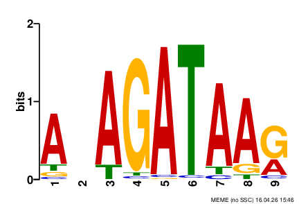

Figure 1: de novo identified motif matched to the GATA3 motif

# 5 visulize peak regions on genome browser

**Single library (normalized)**  
UCSC Genome Browser trackhub link for non-merged, normalized bigWig files: http://guertinlab.cam.uchc.edu/GATA3_PB_hub/hub.txt

# 6 How many reads in the peaks (FRIP)

FRiP (Fraction of Reads in Peaks), is a common quality measurement for PB-seq experiment. It calculates the percentage of all reads that fall in peak regions mapped to the genome. It is important that we always use a universal peak set to calculate the FRiP score for each replicates, then compare between replicates. Usually, we will use the peak set that we generated previously from MACS3, since in that step we have called peaks using all replicates in bam format for the same factor.

## 6.1 400bp window read depth normalization

```bash
cd /home/FCAM/ssun/PBseq/GATA_Deseq2/peakcall0.05
wc -l GATA_PB_summits_final.bed #104132
wc -l GATA_PB_summit_400window.bed #104132

# Counting reads in peaks (400bp window) with `DeSeq2`
cp ../PB_reads.txt .
# cat PB_reads.txt
#       PB_GATA3_1  PB_GATA3_2  PB_GATA3_3  PB_GATA3_4  PB_Mock_1   PB_Mock_2   PB_Mock_3   PB_Mock_4
#   67556170    52471416    37511826    56579626    102753814862572 17970788    16429500

module load R/4.1.2 # this version of `R` on Xanadu has many of our libraries pre-installed.
R
#libraries
library(DESeq2)
library(lattice)
library(dplyr)
library(ggplot2)
library(limma)
library(bigWig)

#functions on github
source('https://raw.githubusercontent.com/mjg54/znf143_pro_seq_analysis/master/docs/ZNF143_functions.R')

#new functions
get.counts.interval <- function(df, path.to.bigWig, file.prefix = 'H') {
    vec.names = c()
    inten.df=data.frame(matrix(ncol = 0, nrow = nrow(df)))

    for (mod.bigWig in Sys.glob(file.path(path.to.bigWig, paste(file.prefix, "*.bigWig", sep ='')))) {
        factor.name = strsplit(strsplit(mod.bigWig, "/")[[1]][length(strsplit(mod.bigWig, "/")[[1]])], '.bigWig')[[1]][1]
        print(factor.name)
        vec.names = c(vec.names, factor.name)
        loaded.bw = load.bigWig(mod.bigWig)
        print(mod.bigWig)
        mod.inten = bed.region.bpQuery.bigWig(loaded.bw, df, abs.value = TRUE)
        inten.df = cbind(inten.df, mod.inten)
    }
    colnames(inten.df) = vec.names
    r.names = paste(df[,1], ':', df[,2], '-', df[,3], sep='')
    row.names(inten.df) = r.names
    return(inten.df)
}

#DeSeq count read size and parse into different quantile
a =  read.table('/home/FCAM/ssun/PBseq/GATA_Deseq2/peakcall0.05/GATA_PB_summit_400window.bed', sep = "\t", header=FALSE)

#non-normalized counts
GATA.counts.df= get.counts.interval(a, "/home/FCAM/ssun/PBseq/260407_NB551647_0123_AH57FJBGYX/Data/Intensities/BaseCalls/Seqoutbias_bw","PB")
sample.conditions <- data.frame(
  row.names = colnames(GATA.counts.df),
  sample.conditions = c("GATA3","GATA3","GATA3","GATA3",
                "Mock","Mock","Mock","Mock")
)
deseq.counts.table = DESeqDataSetFromMatrix(countData =GATA.counts.df , # DESeqDataSet needs countData to be non-negative integers; non-normalized counts are integer, normalized signals has decimals.
                colData = as.data.frame(sample.conditions),
                design = ~ sample.conditions)


GATA.SF <- read.table("PB_reads.txt", sep = '\t', header = TRUE)[,-1] # GATA size factors from read depth
GATA.size.factors = estimateSizeFactorsForMatrix(GATA.SF)
sizeFactors(deseq.counts.table) <- GATA.size.factors
# assign to each column of the count matrix (deseq.counts.table) the size factor to bring each column to a common scale
dds <- DESeq(deseq.counts.table)
normalized.counts.GATA3 = counts(dds, normalized=TRUE)
peak.intensities = rowMeans(normalized.counts.GATA3[,1:4]) # we want to get the average read counts for GATA3 groups

peak.intensities = peak.intensities[which(peak.intensities != 0)]


# making 161 window quantile file
chr = sapply(strsplit(names(peak.intensities), ":"), "[", 1)
rnge = sapply(strsplit(names(peak.intensities), ":"), "[", 2)

quantile(peak.intensities, probs = seq(.05, 1.00, by = .05))


start2 = as.numeric(sapply(strsplit(rnge, "-"), "[", 1)) + 120
end2 = as.numeric(sapply(strsplit(rnge, "-"), "[", 2)) - 120
j =0
q=seq(.05, 1.00, by = .05)
count=0
for (i in quantile(peak.intensities, probs = seq(.05, 1.00, by =
.05)))
{
count = count +1

write.table(file = paste0('quantile', as.character(q[count]), '_summits_161window.bed'), data.frame(chr[peak.intensities > j & peak.intensities <= i], start2[peak.intensities > j & peak.intensities <= i], end2[peak.intensities > j & peak.intensities <= i], peak.intensities[peak.intensities > j & peak.intensities <= i]), sep = '\t', quote=FALSE, col.names=FALSE, row.names=FALSE )
j = i
}

# wc -l quantile0.05_summits_161window.bed
# 5142

options(scipen = 999)
quantile(peak.intensities, probs = seq(.05, 1.00, by = .05))
#        5%        10%        15%        20%        25%        30%        35%
#  12.42913   14.49291   16.00418   17.38888   18.78211   20.32706   21.94463
#       40%        45%        50%        55%        60%        65%        70%
#  23.74917   25.74699   27.99887   30.50441   33.45570   36.89508   40.97625
#       75%        80%        85%        90%        95%       100%
#  45.96799   52.32755   60.79801   72.84185   94.49580 1242.58645



chr = sapply(strsplit(names(peak.intensities), ":"), "[", 1)
rnge = sapply(strsplit(names(peak.intensities), ":"), "[", 2)
start = as.numeric(sapply(strsplit(rnge, "-"), "[", 1)) + 200
end = as.numeric(sapply(strsplit(rnge, "-"), "[", 2)) - 200

# 1bp summit all GATA3 peaks
peak=data.frame(chr, start, end, peak.intensities)
head(peak)
#                      chr   start     end peak.intensities
#chr1:861707-862108   chr1  861907  861908       215.569876
#chr1:879575-879976   chr1  879775  879776        55.382808
#chr1:885648-886049   chr1  885848  885849        22.069708
#chr1:899806-900207   chr1  900006  900007        30.308283
#chr1:1190094-1190495 chr1 1190294 1190295       159.683533
#chr1:1416127-1416528 chr1 1416327 1416328         6.439215
nrow(peak)
#[1] 102830
ranked_peak <- peak[order(-peak[, 4]), ]
write.table(ranked_peak, file = 'GATA_PB_summits_final_DESeq2_ranked_intensity.bed', sep = '\t', quote=FALSE, col.names=FALSE, row.names=FALSE )

save.image('260415_GATA3_PB_deseq.Rdata')
```

## 6.2 Frip

```r
module load bedtools
module load samtools/1.12
peaks=/home/FCAM/ssun/PBseq/GATA_Deseq2/peakcall0.05/GATA_PB_summit_400window.bed

for i in /home/FCAM/ssun/PBseq/260407_NB551647_0123_AH57FJBGYX/Data/Intensities/BaseCalls/*_not_scaled.bed
do
    nm=$(echo $i | awk -F"/" '{print $NF}' | awk -F"_not_scaled.bed" '{print $1}')
    #sort -k1,1 -k2,2n $i > ${nm}_sorted.bed
    mapBed -null '0' -a $peaks -b /home/FCAM/ssun/PBseq/260407_NB551647_0123_AH57FJBGYX/Data/Intensities/BaseCalls/${nm}_sorted.bed > ${nm}_peak_counts.txt
done

for i in *_peak_counts.txt
do
    name=$(echo $i | awk -F"/" '{print $NF}' | awk -F".hg38_peak_counts.txt" '{print $1}')
    echo $name > ${name}_FRiP.txt
    awk '{print $NF}' ${name}.hg38_peak_counts.txt > ${name}_peak_counts_only.txt
    RiP=$(awk '{sum+=$1;} END{print sum;}' ${name}_peak_counts_only.txt) # count the reads in each peak region (from the universal set)
    echo $name | cat - ${name}_peak_counts_only.txt > ${name}_peak_counts.txt
    aligned_reads=$(samtools view -c -f 0x42  /home/FCAM/ssun/PBseq/260407_NB551647_0123_AH57FJBGYX/Data/Intensities/BaseCalls/${name}.sorted.bam) # count the total aligned reads
    FRiP=$(echo "scale=2 ; $RiP / $aligned_reads" | bc)
    echo $FRiP >> ${name}_FRiP.txt
    rm ${name}_peak_counts_only.txt
done

echo -e "chr\tstart\tend\tname\tqvalue" | cat - $peaks | paste -d'\t' - *peak_counts.txt > Combined_GATA_peak_counts.txt
echo -e "Name" > rowname.txt
echo -e "FrIP" >> rowname.txt
paste -d'\t' rowname.txt *FRiP.txt > Combined_GATA_FRiP.txt
rm rowname.txt

# Name  PB_GATA3_1  PB_GATA3_2  PB_GATA3_3  PB_GATA3_4  PB_Mock_1   PB_Mock_2   PB_Mock_3   PB_Mock_4
#FrIP     .26           .28         .24         .32         .05       .05         .04         .05
```

```r
library(lattice)
library(reshape2)
df <- read.table("Combined_GATA_FRiP.txt", header = TRUE, sep = "\t")
df_long <- melt(df, id.vars = "Name",
                variable.name = "Sample",
                value.name = "FRiP")
df_long$Group <- ifelse(grepl("GATA3", df_long$Sample),
                        "GATA3", "Mock")
df_long$Group <- factor(df_long$Group, levels = c("GATA3", "Mock"))

pdf('barplot_GATA3_PBpeak_FRiP.pdf',width=8,height=8)
print(barchart(FRiP ~ Sample,
         data = df_long,
         groups = Group,
         col = c("lightblue", "pink"),
         scales = list(x = list(rot = 45)),
         auto.key = list(space = "right"),
         main = "GATA3 PB peak FRiP",
         xlab = "PB peak FRiP score",
         ylab = "FRiP",
         las = 2))
dev.off()
```

[figure not shown]

Figure 2: Frip

# 7 Exaustive de novo motif analysis in PB-seq peaks

For PB-seq peaks, each peak is expected to contain at least one GATA3 binding site. Based on prior ChIP-seq de novo motif analysis, we expected to identify uniquely oriented and spaced GATA3 motifs in PB-seq peaks that are similar to those observed in ChIP-seq.

However, when performing de novo motif analysis on PB-seq peaks using the MEME Suite, we observed the following:

PB-seq high intensity peaks:  
MEME -> single site GATA3 motif  
GLAM2 -> spaced GATA3 motif

PB-seq low intensity peaks:  
MEME -> spaced GATA3 motif

ChIP-seq high intensity:  
MEME -> spaced GATA3 motif

Although MEME detects only a single GATA-site motif from the top PB-seq peaks, GLAM2 recovers a spaced motif from the same high-intensity PB-seq subset. This suggests that spaced GATA-site configurations are present in high-intensity PB-seq peaks but are not the most dominant ungapped motif signal. In contrast, MEME can recover spaced motifs from high-intensity ChIP-seq peaks, implying that the spaced architecture is more consistently enriched or better aligned relative to the ChIP-seq peak centers in vivo.

Additionally, k-mer analysis further supports that spaced GATA3 motif configurations are enriched in PB-seq peaks.

## 7.1 Updated parse_mast_to_coordinates.R

Path to file: /home/FCAM/ssun/scripts/updated_parse_mast_to_coordinates.R

When parsing the MAST output to the BED file, we calculate the motif coordinates from the TXT file using some hard-coded R scripts. The output BED file from the current `parse_mast_to_coordinates.R` script generates a BED file with motif coordinates. However, there is a discrepancy of one base when transforming the output BED to the FASTA format with `fastaFromBed`.

What I changed is that while calculating the start of motif coordinates, I added a `-1` to the original script:

```r
start[j] = as.numeric(strsplit(strsplit(mast.data[j,1], ":")[[1]][2], "-")[[1]][1]) + mast.data[j,5] -1
```

Now, the output BED file will be one base ahead.  
The updated parse_mast_to_coordinates1.R file correctly reflect the actual coordinates of the motifs.

# 8 GLAM2

Quote from MEME suite: GLAM2 discovers novel, gapped motifs (recurring, variable-length patterns) in your DNA or protein sequences.

## 8.1 Input sequences: GATA3 PB-seq data in vitro

These peak regions are generated from `MACS3 peak calling` using the default stringency and have removed peaks on contigs and within blacklisted regions. The peak intensity is normalized with DeSeq2.  
Peaks are centered at the summit/center of the peak with a 161bp window flanking the center.

```bash
module load bedtools
sizes=/home/FCAM/ssun/Genome/hg38.chrom.sizes
genome=/home/FCAM/ssun/Genome/hg38.fa
dir=/home/FCAM/ssun/PBseq/GATA_Deseq2/peakcall0.05/

# extend the peak region to 161bp window centered on the summit
slopBed -b 80 -i ${dir}GATA_PB_summits_final_DESeq2_ranked_intensity.bed -g $sizes  | sort -k1,1 -k2,2n > GATA_PB_summits_final_DESeq2_ranked_intensity_161bpwindow.bed #102830

# convert to FASTA
fastaFromBed -fi $genome -bed GATA_PB_summits_final_DESeq2_ranked_intensity_161bpwindow.bed -fo GATA_PB_summits_final_DESeq2_ranked_intensity_161bpwindow.fasta #205660
```

```bash
head -5 GATA_PB_summits_final_DESeq2_ranked_intensity_161bpwindow.bed
#chr1   861827  861988  215.56987605857
#chr1   879695  879856  55.3828083151726
#chr1   885768  885929  22.0697079251984
#chr1   899926  900087  30.308282773772
#chr1   1190214 1190375 159.683533257889
```

The first three columns in the bed file are the peak coordinates, notice that they are all 161bp width. The forth column is the peak intensity normaloized via DeSeq2.  
The total number of GATA3 PB-seq peaks is 102830.

## 8.2 GLAM2-all-round1-100bp

working directory: /home/FCAM/ssun/PBseq/Exhaustive_denovomotif_analysis_260410/new_Exaust/GLAM2/glam2_all_PB_100bp

```bash
module load bedtools
sizes=/home/FCAM/ssun/Genome/hg38.chrom.sizes
genome=/home/FCAM/ssun/Genome/hg38.fa
dir=/home/FCAM/ssun/PBseq/GATA_Deseq2/peakcall0.05/

# extend the peak region to 101bp window centered on the summit
slopBed -b 50 -i ${dir}GATA_PB_summits_final_DESeq2_ranked_intensity.bed -g $sizes  | sort -k1,1 -k2,2n > GATA_PB_summits_final_DESeq2_ranked_intensity_101bpwindow.bed #102830

# convert to FASTA
fastaFromBed -fi $genome -bed GATA_PB_summits_final_DESeq2_ranked_intensity_101bpwindow.bed -fo GATA_PB_summits_final_DESeq2_ranked_intensity_101bpwindow.fasta #205660
```

```bash
head -5 GATA_PB_summits_final_DESeq2_ranked_intensity_101bpwindow.bed
#chr1   861857  861958  215.56987605857
#chr1   879725  879826  55.3828083151726
#chr1   885798  885899  22.0697079251984
#chr1   899956  900057  30.308282773772
#chr1   1190244 1190345 159.683533257889
```

```bash
#!/bin/bash
#SBATCH --job-name=Glam2_all.sh
#SBATCH -N 1
#SBATCH -n 32
#SBATCH -c 1
#SBATCH -p general
#SBATCH --qos=general
#SBATCH --mem=128G
#SBATCH --mail-type=ALL
#SBATCH --mail-user=ssun@uchc.edu
#SBATCH -o Glam2_all.sh_%j.out
#SBATCH -e Glam2_all.sh_%j.err

hostname
export TMPDIR="${HOME}/temp"
module load meme/5.5.9

# all PB-seq peaks with 101 window
glam2 -O GATA_PB_all_101win_glam2_output -2 n GATA_PB_summits_final_DESeq2_ranked_intensity_101bpwindow.fasta
```

Conduct a TOMTOM to compare the GLAM2-round1 top motif with the 12 ChIP-seq motif:

```bash
module load meme/5.5.9
module load py-deeptools
module load bedtools
module load R/4.1.2
# concatenate 12 ChIP-seq motifs in one MEME file: "chip_12_motifs.meme"

# get the top Glam2 motif

#wget https://raw.githubusercontent.com/sysunn/siyu_daily_update/main/December_2023/MEME_individual_from_db_python3.py
python ../MEME_individual_from_db_python3_updated.py -i GATA_PB_all_101win_glam2_output/glam2.meme
mkdir Glam2_all_individual_meme
cp 1_meme.txt Glam2_all_individual_meme/Glam2_PB_GATAmotif1_meme.txt
rm *meme.txt


# TOMTOM
tomtom -oc tomtom_glam2_vs_chip12_qval_round1 -eps -thresh 0.05 Glam2_all_individual_meme/Glam2_PB_GATAmotif1_meme.txt chip_12_motifs.meme

head -n 3 tomtom_glam2_vs_chip12_qval_round1/tomtom.tsv
#Query_ID   Target_ID   Optimal_offset  p-value E-value q-value Overlap Query_consensus Target_consensuOrientation
#1  NAGATBNNARNNVWGATA  -2  3.28921e-10 3.94705e-09 7.8941e-09  18  TTTATCTTTTTATTAATCTA    TATCTGTATTGCCATCTC  -
#1  AGATDDDNAGATAAD 0   7.07176e-05 0.000848611 0.000568171 15  TTTATCTTTTTATTAATCTA    TTTATCTTTTCATCT -
```

Among the 12 ChIP-seq motif variants, TOMTOM ranked motif NAGATBNNARNNVWGATA as the closest match to the top GLAM2 motif. Because the target database contained only 12 motifs, significance values were interpreted cautiously.

Mast using the closest matched ChIP-seq motif  
MAST - Given a motif position weight matrix, MAST can search sequences for the occurrence of that motif.  
Usage: http://meme-suite.org/tools/mast

```bash
module load meme/5.5.9
module load py-deeptools
module load bedtools
module load R/4.1.2
genome=/home/FCAM/ssun/Genome/hg38.fa
sizes=/home/FCAM/ssun/Genome/hg38.chrom.sizes

meme_dir="/home/FCAM/ssun/GATA3_ChIP_PRO_July2023/ChIP_final/re_run_exhaustive_denovomotif_260414/single_bash2/individual_meme/"
tomtom_tsv="tomtom_glam2_vs_chip12_qval_round1/tomtom.tsv"

best_target=$(awk 'BEGIN{FS="\t"}
    NR > 1 && $1 !~ /^#/ && NF >= 10 {
        print $2, $6
    }' "$tomtom_tsv" | sort -k2,2g | head -n 1 | awk '{print $1}')
echo "Best TOMTOM Target_ID: $best_target"


matched_file=$(awk -v target="$best_target" '
    /^MOTIF/ {
        if ($2 == target || $3 == target) {
            print FILENAME
            exit
        }
    }
' "$meme_dir"*meme.txt)


# Best TOMTOM Target_ID: NAGATBNNARNNVWGATA
#echo $matched_file
#/home/FCAM/ssun/GATA3_ChIP_PRO_July2023/ChIP_final/re_run_exhaustive_denovomotif_260414/single_bash2/individual_meme/GATAmotif7_meme.txt

mast -mt 0.0001 -hit_list -best  $matched_file GATA_PB_summits_final_DESeq2_ranked_intensity_101bpwindow.fasta > mast_GATA3_PSWM_in_all_PB_peaks_glam2_round1.txt #30808

Rscript /home/FCAM/ssun/scripts/updated_parse_mast_to_coordinates.R mast_GATA3_PSWM_in_all_PB_peaks_glam2_round1.txt
wc -l mast_GATA3_PSWM_in_all_PB_peaks_glam2_round1.bed #30805

# coherence check: check the near mast_cutoff sequences -- evaluate if they are acceptable / match to the spaced motif
genome=/home/FCAM/ssun/Genome/hg38.fa
awk 'BEGIN{OFS="\t"}
{
    p = $5
    if (p >= 0.00009 && p <= 0.0001) {
        name = $1 ":" $2 "-" $3 "|p=" $5 "|strand=" $6
        print $1, $2, $3, name, $5, $6
    }
}' mast_GATA3_PSWM_in_all_PB_peaks_glam2_round1.bed > mast_hits_near_0.0001_round1.bed #354

module load bedtools
bedtools getfasta -fi $genome -bed mast_hits_near_0.0001_round1.bed -fo mast_hits_near_0.0001_round1.fasta -name -s
head mast_hits_near_0.0001_round1.fasta

#>chr1:7925801-7925819|p=9.8e-05|strand=+::chr1:7925801-7925819(+)
#ctgatctgatgggagatg
#>chr1:17801375-17801393|p=9.21e-05|strand=-::chr1:17801375-17801393(-)
#cagataagaggatagatg
#>chr1:39679412-39679430|p=9.21e-05|strand=+::chr1:39679412-39679430(+)
#GAGATAAGAAATAAGATG
#>chr1:40292898-40292916|p=9.21e-05|strand=-::chr1:40292898-40292916(-)
#TTGATGGTAAATTAGATG
#>chr1:50633840-50633858|p=9.8e-05|strand=-::chr1:50633840-50633858(-)
#GAGATAAAATTACAGACA

# Not all sequences near the cutoff perfectly match the motif core 3mer GAT

# change to a more stringent mast_p cut off
mast -mt 0.00005 -hit_list -best  $matched_file GATA_PB_summits_final_DESeq2_ranked_intensity_101bpwindow.fasta > mast_GATA3_PSWM_in_all_PB_peaks_glam2_round1.txt

Rscript /home/FCAM/ssun/scripts/updated_parse_mast_to_coordinates.R mast_GATA3_PSWM_in_all_PB_peaks_glam2_round1.txt
wc -l mast_GATA3_PSWM_in_all_PB_peaks_glam2_round1.bed #28862

# coherence check: check the near mast_cutoff sequences -- evaluate if they are acceptable / match to the spaced motif
genome=/home/FCAM/ssun/Genome/hg38.fa
awk 'BEGIN{OFS="\t"}
{
    p = $5
    if (p >= 0.00004 && p <= 0.00005) {
        name = $1 ":" $2 "-" $3 "|p=" $5 "|strand=" $6
        print $1, $2, $3, name, $5, $6
    }
}' mast_GATA3_PSWM_in_all_PB_peaks_glam2_round1.bed > mast_hits_near_0.00005_round1.bed #842

module load bedtools
bedtools getfasta -fi $genome -bed mast_hits_near_0.00005_round1.bed -fo mast_hits_near_0.00005_round1.fasta -name -s
head mast_hits_near_0.00005_round1.fasta

#>chr1:4943848-4943866|p=4.28e-05|strand=-::chr1:4943848-4943866(-)
#tagatagattggtagata
#>chr1:6876740-6876758|p=4.28e-05|strand=+::chr1:6876740-6876758(+)
#CAGATTTTGTTTGTGATT
#>chr1:25997130-25997148|p=4.28e-05|strand=+::chr1:25997130-25997148(+)
#AAGATACAGTCCAAGATA
#>chr1:26419200-26419218|p=4.28e-05|strand=+::chr1:26419200-26419218(+)
#CTGATTACCTATCTGATA
#>chr1:35891514-35891532|p=4.97e-05|strand=+::chr1:35891514-35891532(+)
#TAGAttctgttcctgatt

# now looks much much better
```

```r
# Use `intersectBed` to find GATA3 peaks without motif 1. And convert to FASTA.
intersectBed -v -a GATA_PB_summits_final_DESeq2_ranked_intensity_101bpwindow.bed -b mast_GATA3_PSWM_in_all_PB_peaks_glam2_round1.bed > PB_without_glam2_motifs_1.bed #73967
fastaFromBed -fi $genome -bed PB_without_glam2_motifs_1.bed -fo PB_without_glam2_motifs_1.fasta
```

## 8.3 GLAM2-all-round2-100bp

```bash
#!/bin/bash
#SBATCH --job-name=Glam2_all_round2.sh
#SBATCH -N 1
#SBATCH -n 32
#SBATCH -c 1
#SBATCH -p general
#SBATCH --qos=general
#SBATCH --mem=128G
#SBATCH --mail-type=ALL
#SBATCH --mail-user=ssun@uchc.edu
#SBATCH -o Glam2_all_round2.sh_%j.out
#SBATCH -e Glam2_all_round2.sh_%j.err

hostname
export TMPDIR="${HOME}/temp"
module load meme/5.5.9

# all PB-seq peaks with 101 window
glam2 -O GATA_PB_all_101win_glam2_round2_output -2 n PB_without_glam2_motifs_1.fasta
```

The output top motif is a degenerate tandem-14 motif (this is new, not been previously reported by ChIP-seq).  
The second motif is a tandem-10 motif.

I prioritize on using the tandem-10 motif as the second round motif.

Conduct a TOMTOM to compare the GLAM2-round2 top motif with the 12 ChIP-seq motif:

```bash
module load meme/5.5.9
module load py-deeptools
module load bedtools
module load R/4.1.2
# concatenate 12 ChIP-seq motifs in one MEME file: "chip_12_motifs.meme"

# get the top Glam2 motif

#wget https://raw.githubusercontent.com/sysunn/siyu_daily_update/main/December_2023/MEME_individual_from_db_python3.py
python ../MEME_individual_from_db_python3_updated.py -i GATA_PB_all_101win_glam2_round2_output/glam2.meme
#mkdir Glam2_all_individual_meme
cp 2_meme.txt Glam2_all_individual_meme/Glam2_PB_GATAmotif2_meme.txt
rm *meme.txt


# TOMTOM
tomtom -oc tomtom_glam2_vs_chip12_qval_round2 -eps -thresh 0.05 Glam2_all_individual_meme/Glam2_PB_GATAmotif2_meme.txt chip_12_motifs.meme

head -n 3 tomtom_glam2_vs_chip12_qval_round2/tomtom.tsv
#Query_ID   Target_ID   Optimal_offset  p-value E-value q-value Overlap Query_consensus Target_consensuOrientation
#2  YTTATCTYYNNHVATCT   -2  1.15797e-09 1.38956e-08 2.77912e-08 17  TTCTTATCTTTTATAATCTT    CTTATCTTTTCCAATCT   +
#2  AGATGRVAGATAA   -3  5.34715e-05 0.000641658 0.000641658 13  TTCTTATCTTTTATAATCTT    TTATCTCTCATCT   -
```

Among the 12 ChIP-seq motif variants, TOMTOM ranked motif YTTATCTYYNNHVATCT as the closest match to the top GLAM2 motif. Because the target database contained only 12 motifs, significance values were interpreted cautiously.

Mast using the closest matched ChIP-seq motif  
MAST - Given a motif position weight matrix, MAST can search sequences for the occurrence of that motif.  
Usage: http://meme-suite.org/tools/mast

```bash
module load meme/5.5.9
module load py-deeptools
module load bedtools
module load R/4.1.2
genome=/home/FCAM/ssun/Genome/hg38.fa
sizes=/home/FCAM/ssun/Genome/hg38.chrom.sizes

meme_dir="/home/FCAM/ssun/GATA3_ChIP_PRO_July2023/ChIP_final/re_run_exhaustive_denovomotif_260414/single_bash2/individual_meme/"
tomtom_tsv="tomtom_glam2_vs_chip12_qval_round2/tomtom.tsv"

best_target=$(awk 'BEGIN{FS="\t"}
    NR > 1 && $1 !~ /^#/ && NF >= 10 {
        print $2, $6
    }' "$tomtom_tsv" | sort -k2,2g | head -n 1 | awk '{print $1}')
echo "Best TOMTOM Target_ID: $best_target"


matched_file=$(awk -v target="$best_target" '
    /^MOTIF/ {
        if ($2 == target || $3 == target) {
            print FILENAME
            exit
        }
    }
' "$meme_dir"*meme.txt)


# Best TOMTOM Target_ID: YTTATCTYYNNHVATCT
# echo $matched_file
# /home/FCAM/ssun/GATA3_ChIP_PRO_July2023/ChIP_final/re_run_exhaustive_denovomotif_260414/single_bash2/individual_meme/GATAmotif8_meme.txt

mast -mt 0.0001 -hit_list -best  $matched_file PB_without_glam2_motifs_1.fasta > mast_GATA3_PSWM_in_all_PB_peaks_glam2_round2.txt #7159

Rscript /home/FCAM/ssun/scripts/updated_parse_mast_to_coordinates.R mast_GATA3_PSWM_in_all_PB_peaks_glam2_round2.txt
wc -l mast_GATA3_PSWM_in_all_PB_peaks_glam2_round2.bed #7156

# coherence check: check the near mast_cutoff sequences -- evaluate if they are acceptable / match to the spaced motif
genome=/home/FCAM/ssun/Genome/hg38.fa
awk 'BEGIN{OFS="\t"}
{
    p = $5
    if (p >= 0.00009 && p <= 0.0001) {
        name = $1 ":" $2 "-" $3 "|p=" $5 "|strand=" $6
        print $1, $2, $3, name, $5, $6
    }
}' mast_GATA3_PSWM_in_all_PB_peaks_glam2_round2.bed > mast_hits_near_0.0001_round2.bed #240

module load bedtools
bedtools getfasta -fi $genome -bed mast_hits_near_0.0001_round2.bed -fo mast_hits_near_0.0001_round2.fasta -name -s
head mast_hits_near_0.0001_round2.fasta

#>chr1:11140819-11140836|p=9.75e-05|strand=-::chr1:11140819-11140836(-)
#TTTATCAGTGATAGTCA
#>chr1:17801395-17801412|p=9.31e-05|strand=-::chr1:17801395-17801412(-)
#tttatcaacgtatattt
#>chr1:24398560-24398577|p=9.75e-05|strand=-::chr1:24398560-24398577(-)
#gtaatctgtgaaaatga
#>chr1:35569695-35569712|p=9.75e-05|strand=-::chr1:35569695-35569712(-)
#ATAATCTGAAGAGATCA
#>chr1:49044654-49044671|p=9.75e-05|strand=-::chr1:49044654-49044671(-)
#ataatccaggttaatct

# Not all sequences near the cutoff perfectly match the motif core 3mer GAT

# change to a more stringent mast_p cut off
mast -mt 0.00005 -hit_list -best  $matched_file PB_without_glam2_motifs_1.fasta > mast_GATA3_PSWM_in_all_PB_peaks_glam2_round2.txt #5380

Rscript /home/FCAM/ssun/scripts/updated_parse_mast_to_coordinates.R mast_GATA3_PSWM_in_all_PB_peaks_glam2_round2.txt
wc -l mast_GATA3_PSWM_in_all_PB_peaks_glam2_round2.bed #5377

# coherence check: check the near mast_cutoff sequences -- evaluate if they are acceptable / match to the spaced motif
genome=/home/FCAM/ssun/Genome/hg38.fa
awk 'BEGIN{OFS="\t"}
{
    p = $5
    if (p >= 0.00004 && p <= 0.00005) {
        name = $1 ":" $2 "-" $3 "|p=" $5 "|strand=" $6
        print $1, $2, $3, name, $5, $6
    }
}' mast_GATA3_PSWM_in_all_PB_peaks_glam2_round2.bed > mast_hits_near_0.00005_round2.bed #842

module load bedtools
bedtools getfasta -fi $genome -bed mast_hits_near_0.00005_round2.bed -fo mast_hits_near_0.00005_round2.fasta -name -s
head mast_hits_near_0.00005_round2.fasta

#>chr1:28449421-28449438|p=4.78e-05|strand=+::chr1:28449421-28449438(+)
#TTAATCCTGTTTTATCT
#>chr1:33294209-33294226|p=4.02e-05|strand=+::chr1:33294209-33294226(+)
#attatctgatgttatct
#>chr1:57885125-57885142|p=4.02e-05|strand=+::chr1:57885125-57885142(+)
#TTTATCTCAATAGATGT
#>chr1:66440423-66440440|p=4.02e-05|strand=+::chr1:66440423-66440440(+)
#ctaatcattgatgattt
#>chr1:68208217-68208234|p=4.52e-05|strand=+::chr1:68208217-68208234(+)
#ATTATCTTCACAAATTA

# change to a more stringent mast_p cut off
mast -mt 0.000005 -hit_list -best  $matched_file PB_without_glam2_motifs_1.fasta > mast_GATA3_PSWM_in_all_PB_peaks_glam2_round2.txt #2506

Rscript /home/FCAM/ssun/scripts/updated_parse_mast_to_coordinates.R mast_GATA3_PSWM_in_all_PB_peaks_glam2_round2.txt
wc -l mast_GATA3_PSWM_in_all_PB_peaks_glam2_round2.bed #2503

# coherence check: check the near mast_cutoff sequences -- evaluate if they are acceptable / match to the spaced motif
genome=/home/FCAM/ssun/Genome/hg38.fa
awk 'BEGIN{OFS="\t"}
{
    p = $5
    if (p >= 0.000004 && p <= 0.000005) {
        name = $1 ":" $2 "-" $3 "|p=" $5 "|strand=" $6
        print $1, $2, $3, name, $5, $6
    }
}' mast_GATA3_PSWM_in_all_PB_peaks_glam2_round2.bed > mast_hits_near_0.000005_round2.bed #

module load bedtools
bedtools getfasta -fi $genome -bed mast_hits_near_0.000005_round2.bed -fo mast_hits_near_0.000005_round2.fasta -name -s
head mast_hits_near_0.000005_round2.fasta

#>chr1:5604140-5604157|p=4.74e-06|strand=+::chr1:5604140-5604157(+)
#tctatctctttctatct
#>chr1:32833895-32833912|p=4.74e-06|strand=-::chr1:32833895-32833912(-)
#gtaatcattaaaaatct
#>chr1:50464722-50464739|p=4.74e-06|strand=+::chr1:50464722-50464739(+)
#attatcacttttgatct
#>chr1:75578402-75578419|p=4.3e-06|strand=-::chr1:75578402-75578419(-)
#tctatCTCTATCAATCA
#>chr1:90933807-90933824|p=4.74e-06|strand=-::chr1:90933807-90933824(-)
#gctatcttacctaatct
```

```r
# Use `intersectBed` to find GATA3 peaks without motif 1. And convert to FASTA.
intersectBed -v -a PB_without_glam2_motifs_1.bed -b mast_GATA3_PSWM_in_all_PB_peaks_glam2_round2.bed > PB_without_glam2_motifs_12.bed # 71464
fastaFromBed -fi $genome -bed PB_without_glam2_motifs_12.bed -fo PB_without_glam2_motifs_12.fasta
```

## 8.4 GLAM2-all-round3-100bp

```bash
#!/bin/bash
#SBATCH --job-name=Glam2_all_round3.sh
#SBATCH -N 1
#SBATCH -n 32
#SBATCH -c 1
#SBATCH -p general
#SBATCH --qos=general
#SBATCH --mem=128G
#SBATCH --mail-type=ALL
#SBATCH --mail-user=ssun@uchc.edu
#SBATCH -o Glam2_all_round3.sh_%j.out
#SBATCH -e Glam2_all_round3.sh_%j.err

hostname
export TMPDIR="${HOME}/temp"
module load meme/5.5.9

# all PB-seq peaks with 101 window
glam2 -O GATA_PB_all_101win_glam2_round3_output -2 n PB_without_glam2_motifs_12.fasta
```

Conduct a TOMTOM to compare the GLAM2-round3 top motif with the 12 ChIP-seq motif:

```bash
module load meme/5.5.9
module load py-deeptools
module load bedtools
module load R/4.1.2
# concatenate 12 ChIP-seq motifs in one MEME file: "chip_12_motifs.meme"

# get the top Glam2 motif

#wget https://raw.githubusercontent.com/sysunn/siyu_daily_update/main/December_2023/MEME_individual_from_db_python3.py
python ../MEME_individual_from_db_python3_updated.py -i GATA_PB_all_101win_glam2_round3_output/glam2.meme
#mkdir Glam2_all_individual_meme
cp 1_meme.txt Glam2_all_individual_meme/Glam2_PB_GATAmotif3_meme.txt
rm *meme.txt


# TOMTOM
tomtom -oc tomtom_glam2_vs_chip12_qval_round3 -eps -thresh 0.05 Glam2_all_individual_meme/Glam2_PB_GATAmotif3_meme.txt chip_12_motifs.meme

head -n 3 tomtom_glam2_vs_chip12_qval_round3/tomtom.tsv
#Query_ID   Target_ID   Optimal_offset  p-value E-value q-value Overlap Query_consensus Target_consensuOrientation
#1  AGATDDDNAGATAAD 0   2.93566e-11 3.5228e-10  7.0456e-10  15  AGATTAAAAGATAAGAATCT    AGATGAAAAGATAAA +
#1  21-AGATAAGG -8  0.000157469 0.00188963  0.00110385  AGATTAAAAGATAAGAATCT    AGATAAGG    +
```

Among the 12 ChIP-seq motif variants, TOMTOM ranked motif AGATDDDNAGATAAD as the closest match to the top GLAM2 motif. Because the target database contained only 12 motifs, significance values were interpreted cautiously.

Mast using the closest matched ChIP-seq motif  
MAST - Given a motif position weight matrix, MAST can search sequences for the occurrence of that motif.  
Usage: http://meme-suite.org/tools/mast

```bash
module load meme/5.5.9
module load py-deeptools
module load bedtools
module load R/4.1.2
genome=/home/FCAM/ssun/Genome/hg38.fa
sizes=/home/FCAM/ssun/Genome/hg38.chrom.sizes

meme_dir="/home/FCAM/ssun/GATA3_ChIP_PRO_July2023/ChIP_final/re_run_exhaustive_denovomotif_260414/single_bash2/individual_meme/"
tomtom_tsv="tomtom_glam2_vs_chip12_qval_round3/tomtom.tsv"

best_target=$(awk 'BEGIN{FS="\t"}
    NR > 1 && $1 !~ /^#/ && NF >= 10 {
        print $2, $6
    }' "$tomtom_tsv" | sort -k2,2g | head -n 1 | awk '{print $1}')
echo "Best TOMTOM Target_ID: $best_target"


matched_file=$(awk -v target="$best_target" '
    /^MOTIF/ {
        if ($2 == target || $3 == target) {
            print FILENAME
            exit
        }
    }
' "$meme_dir"*meme.txt)


# Best TOMTOM Target_ID: AGATDDDNAGATAAD

# echo $matched_file
# /home/FCAM/ssun/GATA3_ChIP_PRO_July2023/ChIP_final/re_run_exhaustive_denovomotif_260414/single_bash2/individual_meme/GATAmotif3_meme.txt

mast -mt 0.0001 -hit_list -best  $matched_file PB_without_glam2_motifs_12.fasta > mast_GATA3_PSWM_in_all_PB_peaks_glam2_round3.txt #13135

Rscript /home/FCAM/ssun/scripts/updated_parse_mast_to_coordinates.R mast_GATA3_PSWM_in_all_PB_peaks_glam2_round3.txt
wc -l mast_GATA3_PSWM_in_all_PB_peaks_glam2_round3.bed #13132

# coherence check: check the near mast_cutoff sequences -- evaluate if they are acceptable / match to the spaced motif
genome=/home/FCAM/ssun/Genome/hg38.fa
awk 'BEGIN{OFS="\t"}
{
    p = $5
    if (p >= 0.00009 && p <= 0.0001) {
        name = $1 ":" $2 "-" $3 "|p=" $5 "|strand=" $6
        print $1, $2, $3, name, $5, $6
    }
}' mast_GATA3_PSWM_in_all_PB_peaks_glam2_round3.bed > mast_hits_near_0.0001_round3.bed #

module load bedtools
bedtools getfasta -fi $genome -bed mast_hits_near_0.0001_round3.bed -fo mast_hits_near_0.0001_round3.fasta -name -s
head mast_hits_near_0.0001_round3.fasta

#>chr1:13993520-13993535|p=9.77e-05|strand=+::chr1:13993520-13993535(+)
#AGATTGAATGGTAGT
#>chr1:27833840-27833855|p=9.77e-05|strand=+::chr1:27833840-27833855(+)
#AGATAACCAGGTATT
#>chr1:53431945-53431960|p=9.33e-05|strand=+::chr1:53431945-53431960(+)
#AGATCAATGGATGAG
#>chr1:65071115-65071130|p=9.33e-05|strand=-::chr1:65071115-65071130(-)
#TGATTCTtagatgat
#>chr1:91870170-91870185|p=9.77e-05|strand=-::chr1:91870170-91870185(-)
#TGATAAAATGGTTAG

# Not all sequences near the cutoff perfectly match the motif core 3mer GAT

# change to a more stringent mast_p cut off
mast -mt 0.00005 -hit_list -best  $matched_file PB_without_glam2_motifs_12.fasta > mast_GATA3_PSWM_in_all_PB_peaks_glam2_round3.txt #12227

Rscript /home/FCAM/ssun/scripts/updated_parse_mast_to_coordinates.R mast_GATA3_PSWM_in_all_PB_peaks_glam2_round3.txt
wc -l mast_GATA3_PSWM_in_all_PB_peaks_glam2_round3.bed #12224

# coherence check: check the near mast_cutoff sequences -- evaluate if they are acceptable / match to the spaced motif
genome=/home/FCAM/ssun/Genome/hg38.fa
awk 'BEGIN{OFS="\t"}
{
    p = $5
    if (p >= 0.00004 && p <= 0.00005) {
        name = $1 ":" $2 "-" $3 "|p=" $5 "|strand=" $6
        print $1, $2, $3, name, $5, $6
    }
}' mast_GATA3_PSWM_in_all_PB_peaks_glam2_round3.bed > mast_hits_near_0.00005_round3.bed #

module load bedtools
bedtools getfasta -fi $genome -bed mast_hits_near_0.00005_round3.bed -fo mast_hits_near_0.00005_round3.fasta -name -s
head mast_hits_near_0.00005_round3.fasta

#>chr1:5603392-5603407|p=4.55e-05|strand=-::chr1:5603392-5603407(-)
#agatatagagatgga
#>chr1:20450313-20450328|p=4.27e-05|strand=+::chr1:20450313-20450328(+)
#tGATtgcaagattgt
#>chr1:21425737-21425752|p=4.84e-05|strand=-::chr1:21425737-21425752(-)
#TGATATTGGGATAAT
#>chr1:21482250-21482265|p=4.84e-05|strand=+::chr1:21482250-21482265(+)
#TGATATTGGGATAAT
#>chr1:25610794-25610809|p=4.27e-05|strand=-::chr1:25610794-25610809(-)
#tgatgtgaggattag
```

```r
# Use `intersectBed` to find GATA3 peaks without motif 12. And convert to FASTA.
intersectBed -v -a PB_without_glam2_motifs_12.bed -b mast_GATA3_PSWM_in_all_PB_peaks_glam2_round3.bed > PB_without_glam2_motifs_123.bed # 59239
fastaFromBed -fi $genome -bed PB_without_glam2_motifs_123.bed -fo PB_without_glam2_motifs_123.fasta
```

## 8.5 GLAM2-all-round4-100bp

```bash
#!/bin/bash
#SBATCH --job-name=Glam2_all_round4.sh
#SBATCH -N 1
#SBATCH -n 32
#SBATCH -c 1
#SBATCH -p general
#SBATCH --qos=general
#SBATCH --mem=128G
#SBATCH --mail-type=ALL
#SBATCH --mail-user=ssun@uchc.edu
#SBATCH -o Glam2_all_round4.sh_%j.out
#SBATCH -e Glam2_all_round4.sh_%j.err

hostname
export TMPDIR="${HOME}/temp"
module load meme/5.5.9

# all PB-seq peaks with 101 window
glam2 -O GATA_PB_all_101win_glam2_round4_output -2 n PB_without_glam2_motifs_123.fasta
```

tandem-13

Conduct a TOMTOM to compare the GLAM2-round3 top motif with the 12 ChIP-seq motif:

```bash
module load meme/5.5.9
module load py-deeptools
module load bedtools
module load R/4.1.2
# concatenate 12 ChIP-seq motifs in one MEME file: "chip_12_motifs.meme"

# get the top Glam2 motif

#wget https://raw.githubusercontent.com/sysunn/siyu_daily_update/main/December_2023/MEME_individual_from_db_python3.py
python ../MEME_individual_from_db_python3_updated.py -i GATA_PB_all_101win_glam2_round4_output/glam2.meme
#mkdir Glam2_all_individual_meme
cp 1_meme.txt Glam2_all_individual_meme/Glam2_PB_GATAmotif4_meme.txt
rm *meme.txt


# TOMTOM
tomtom -oc tomtom_glam2_vs_chip12_qval_round4 -eps -thresh 0.05 Glam2_all_individual_meme/Glam2_PB_GATAmotif4_meme.txt chip_12_motifs.meme

head -n 3 tomtom_glam2_vs_chip12_qval_round4/tomtom.tsv
#Query_ID   Target_ID   Optimal_offset  p-value E-value q-value Overlap Query_consensus Target_consensuOrientation
#1  AGATBNNNNNNVNWGATAA 0   3.73993e-10 4.48791e-09 8.97583e-09 19  TTATCTTTTTTATATATCTT    TTATCTGTATTTGACATCT -
#1  TTATCTBYNNVATCT 0   5.50119e-05 0.000660143 0.000660143 15  TTATCTTTTTTATATATCTT    TTATCTCTTTCATCT +
```

Among the 12 ChIP-seq motif variants, TOMTOM ranked motif AGATBNNNNNNVNWGATAA as the closest match to the top GLAM2 motif. Because the target database contained only 12 motifs, significance values were interpreted cautiously.

Mast using the closest matched ChIP-seq motif  
MAST - Given a motif position weight matrix, MAST can search sequences for the occurrence of that motif.  
Usage: http://meme-suite.org/tools/mast

```bash
module load meme/5.5.9
module load py-deeptools
module load bedtools
module load R/4.1.2
genome=/home/FCAM/ssun/Genome/hg38.fa
sizes=/home/FCAM/ssun/Genome/hg38.chrom.sizes

meme_dir="/home/FCAM/ssun/GATA3_ChIP_PRO_July2023/ChIP_final/re_run_exhaustive_denovomotif_260414/single_bash2/individual_meme/"
tomtom_tsv="tomtom_glam2_vs_chip12_qval_round4/tomtom.tsv"

best_target=$(awk 'BEGIN{FS="\t"}
    NR > 1 && $1 !~ /^#/ && NF >= 10 {
        print $2, $6
    }' "$tomtom_tsv" | sort -k2,2g | head -n 1 | awk '{print $1}')
echo "Best TOMTOM Target_ID: $best_target"


matched_file=$(awk -v target="$best_target" '
    /^MOTIF/ {
        if ($2 == target || $3 == target) {
            print FILENAME
            exit
        }
    }
' "$meme_dir"*meme.txt)


# Best TOMTOM Target_ID: AGATBNNNNNNVNWGATAA

# echo $matched_file
# /home/FCAM/ssun/GATA3_ChIP_PRO_July2023/ChIP_final/re_run_exhaustive_denovomotif_260414/single_bash2/individual_meme/GATAmotif6_meme.txt

mast -mt 0.0001 -hit_list -best  $matched_file PB_without_glam2_motifs_123.fasta > mast_GATA3_PSWM_in_all_PB_peaks_glam2_round4.txt

Rscript /home/FCAM/ssun/scripts/updated_parse_mast_to_coordinates.R mast_GATA3_PSWM_in_all_PB_peaks_glam2_round4.txt
wc -l mast_GATA3_PSWM_in_all_PB_peaks_glam2_round4.bed #21499

# coherence check: check the near mast_cutoff sequences -- evaluate if they are acceptable / match to the spaced motif
genome=/home/FCAM/ssun/Genome/hg38.fa
awk 'BEGIN{OFS="\t"}
{
    p = $5
    if (p >= 0.00009 && p <= 0.0001) {
        name = $1 ":" $2 "-" $3 "|p=" $5 "|strand=" $6
        print $1, $2, $3, name, $5, $6
    }
}' mast_GATA3_PSWM_in_all_PB_peaks_glam2_round4.bed > mast_hits_near_0.0001_round4.bed #

module load bedtools
bedtools getfasta -fi $genome -bed mast_hits_near_0.0001_round4.bed -fo mast_hits_near_0.0001_round4.fasta -name -s
head mast_hits_near_0.0001_round4.fasta

#>chr1:74979590-74979609|p=9.6e-05|strand=+::chr1:74979590-74979609(+)
#AGACCCAATGAAGAGATTA
#>chr1:103373766-103373785|p=9.01e-05|strand=-::chr1:103373766-103373785(-)
#AGACTGGAAATAAAGATTT
#>chr1:167474257-167474276|p=9.6e-05|strand=+::chr1:167474257-167474276(+)
#AGACTTTAAAGTCAGATTT
#>chr1:190764275-190764294|p=9.6e-05|strand=+::chr1:190764275-190764294(+)
#TGATAATGAGAAGCGATAG
#>chr1:212755652-212755671|p=9.6e-05|strand=+::chr1:212755652-212755671(+)
#agacacagcaaactgataa


# Not all sequences near the cutoff perfectly match the motif core 3mer GAT

# change to a more stringent mast_p cut off
mast -mt 0.00005 -hit_list -best  $matched_file PB_without_glam2_motifs_123.fasta > mast_GATA3_PSWM_in_all_PB_peaks_glam2_round4.txt

Rscript /home/FCAM/ssun/scripts/updated_parse_mast_to_coordinates.R mast_GATA3_PSWM_in_all_PB_peaks_glam2_round4.txt
wc -l mast_GATA3_PSWM_in_all_PB_peaks_glam2_round4.bed #20994

# coherence check: check the near mast_cutoff sequences -- evaluate if they are acceptable / match to the spaced motif
genome=/home/FCAM/ssun/Genome/hg38.fa
awk 'BEGIN{OFS="\t"}
{
    p = $5
    if (p >= 0.00004 && p <= 0.00005) {
        name = $1 ":" $2 "-" $3 "|p=" $5 "|strand=" $6
        print $1, $2, $3, name, $5, $6
    }
}' mast_GATA3_PSWM_in_all_PB_peaks_glam2_round4.bed > mast_hits_near_0.00005_round4.bed #

module load bedtools
bedtools getfasta -fi $genome -bed mast_hits_near_0.00005_round4.bed -fo mast_hits_near_0.00005_round4.fasta -name -s
head mast_hits_near_0.00005_round4.fasta

#>chr1:40140441-40140460|p=4.2e-05|strand=+::chr1:40140441-40140460(+)
#tgataatatttacagattc
#>chr1:42226835-42226854|p=4.4e-05|strand=-::chr1:42226835-42226854(-)
#AGATCTCAAACTGGGATTA
#>chr1:61644478-61644497|p=4.2e-05|strand=+::chr1:61644478-61644497(+)
#AGATCTGGATTCTGGATAA
#>chr1:81236755-81236774|p=4.81e-05|strand=-::chr1:81236755-81236774(-)
#TGATTTTCATATGTGATTT
#>chr1:91748551-91748570|p=4.81e-05|strand=+::chr1:91748551-91748570(+)
#TGATGCGATGCCCTGATTT
```

```r
# Use `intersectBed` to find GATA3 peaks without motif 12. And convert to FASTA.
intersectBed -v -a PB_without_glam2_motifs_123.bed -b mast_GATA3_PSWM_in_all_PB_peaks_glam2_round4.bed > PB_without_glam2_motifs_1234.bed # 38243
fastaFromBed -fi $genome -bed PB_without_glam2_motifs_1234.bed -fo PB_without_glam2_motifs_1234.fasta
```

## 8.6 GLAM2-all-round5-100bp

```bash
#!/bin/bash
#SBATCH --job-name=Glam2_all_round5.sh
#SBATCH -N 1
#SBATCH -n 32
#SBATCH -c 1
#SBATCH -p general
#SBATCH --qos=general
#SBATCH --mem=128G
#SBATCH --mail-type=ALL
#SBATCH --mail-user=ssun@uchc.edu
#SBATCH -o Glam2_all_round5.sh_%j.out
#SBATCH -e Glam2_all_round5.sh_%j.err

hostname
export TMPDIR="${HOME}/temp"
module load meme/5.5.9

# all PB-seq peaks with 101 window
glam2 -O GATA_PB_all_101win_glam2_round5_output -2 n PB_without_glam2_motifs_1234.fasta
```

Conduct a TOMTOM to compare the GLAM2-round3 top motif with the 12 ChIP-seq motif:

```bash
module load meme/5.5.9
module load py-deeptools
module load bedtools
module load R/4.1.2
# concatenate 12 ChIP-seq motifs in one MEME file: "chip_12_motifs.meme"

# get the top Glam2 motif

#wget https://raw.githubusercontent.com/sysunn/siyu_daily_update/main/December_2023/MEME_individual_from_db_python3.py
python ../MEME_individual_from_db_python3_updated.py -i GATA_PB_all_101win_glam2_round5_output/glam2.meme
#mkdir Glam2_all_individual_meme
cp 1_meme.txt Glam2_all_individual_meme/Glam2_PB_GATAmotif5_meme.txt
rm *meme.txt


# TOMTOM
tomtom -oc tomtom_glam2_vs_chip12_qval_round5 -eps -thresh 0.05 Glam2_all_individual_meme/Glam2_PB_GATAmotif5_meme.txt chip_12_motifs.meme

head -n 3 tomtom_glam2_vs_chip12_qval_round5/tomtom.tsv
#Query_ID   Target_ID   Optimal_offset  p-value E-value q-value Overlap Query_consensus Target_consensuOrientation
#1  AGATBYTTATC -8  4.89996e-07 5.87995e-06 1.17599e-05 11  TTTTTTTTAGATCTTTATCT    AGATTTTTATC +
#1  21-AGATAAGG -12 0.000918569 0.0110228   0.0110228   TTTTTTTTAGATCTTTATCT    CCTTATCT    -
```

Among the 12 ChIP-seq motif variants, TOMTOM ranked motif AGATBYTTATC as the closest match to the top GLAM2 motif. Because the target database contained only 12 motifs, significance values were interpreted cautiously.

Mast using the closest matched ChIP-seq motif  
MAST - Given a motif position weight matrix, MAST can search sequences for the occurrence of that motif.  
Usage: http://meme-suite.org/tools/mast

```bash
module load meme/5.5.9
module load py-deeptools
module load bedtools
module load R/4.1.2
genome=/home/FCAM/ssun/Genome/hg38.fa
sizes=/home/FCAM/ssun/Genome/hg38.chrom.sizes

meme_dir="/home/FCAM/ssun/GATA3_ChIP_PRO_July2023/ChIP_final/re_run_exhaustive_denovomotif_260414/single_bash2/individual_meme/"
tomtom_tsv="tomtom_glam2_vs_chip12_qval_round5/tomtom.tsv"

best_target=$(awk 'BEGIN{FS="\t"}
    NR > 1 && $1 !~ /^#/ && NF >= 10 {
        print $2, $6
    }' "$tomtom_tsv" | sort -k2,2g | head -n 1 | awk '{print $1}')
echo "Best TOMTOM Target_ID: $best_target"


matched_file=$(awk -v target="$best_target" '
    /^MOTIF/ {
        if ($2 == target || $3 == target) {
            print FILENAME
            exit
        }
    }
' "$meme_dir"*meme.txt)


# Best TOMTOM Target_ID: AGATBYTTATC

# echo $matched_file
# /home/FCAM/ssun/GATA3_ChIP_PRO_July2023/ChIP_final/re_run_exhaustive_denovomotif_260414/single_bash2/individual_meme/GATAmotif2_meme.txt

mast -mt 0.0001 -hit_list -best  $matched_file PB_without_glam2_motifs_1234.fasta > mast_GATA3_PSWM_in_all_PB_peaks_glam2_round5.txt

Rscript /home/FCAM/ssun/scripts/updated_parse_mast_to_coordinates.R mast_GATA3_PSWM_in_all_PB_peaks_glam2_round5.txt
wc -l mast_GATA3_PSWM_in_all_PB_peaks_glam2_round5.bed #9700

# coherence check: check the near mast_cutoff sequences -- evaluate if they are acceptable / match to the spaced motif
genome=/home/FCAM/ssun/Genome/hg38.fa
awk 'BEGIN{OFS="\t"}
{
    p = $5
    if (p >= 0.00009 && p <= 0.0001) {
        name = $1 ":" $2 "-" $3 "|p=" $5 "|strand=" $6
        print $1, $2, $3, name, $5, $6
    }
}' mast_GATA3_PSWM_in_all_PB_peaks_glam2_round5.bed > mast_hits_near_0.0001_round5.bed #

module load bedtools
bedtools getfasta -fi $genome -bed mast_hits_near_0.0001_round5.bed -fo mast_hits_near_0.0001_round5.fasta -name -s
head mast_hits_near_0.0001_round5.fasta

#>chr1:11493422-11493433|p=9.57e-05|strand=+::chr1:11493422-11493433(+)
#tgatgctgatc
#>chr1:239048387-239048398|p=9.57e-05|strand=+::chr1:239048387-239048398(+)
#TGATGCAAATC
#>chr10:5450647-5450658|p=9.57e-05|strand=-::chr10:5450647-5450658(-)
#TGATGAGAATC
#>chr10:55048691-55048702|p=9.3e-05|strand=-::chr10:55048691-55048702(-)
#tgataaatatC
#>chr12:82403228-82403239|p=9.3e-05|strand=-::chr12:82403228-82403239(-)
#TGATCCAAATC
```

```r
# Use `intersectBed` to find GATA3 peaks without motif 12. And convert to FASTA.
intersectBed -v -a PB_without_glam2_motifs_1234.bed -b mast_GATA3_PSWM_in_all_PB_peaks_glam2_round5.bed > PB_without_glam2_motifs_12345.bed # 28543
fastaFromBed -fi $genome -bed PB_without_glam2_motifs_12345.bed -fo PB_without_glam2_motifs_12345.fasta
```

## 8.7 GLAM2-all-round6-100bp

```bash
#!/bin/bash
#SBATCH --job-name=Glam2_all_round6.sh
#SBATCH -N 1
#SBATCH -n 32
#SBATCH -c 1
#SBATCH -p general
#SBATCH --qos=general
#SBATCH --mem=128G
#SBATCH --mail-type=ALL
#SBATCH --mail-user=ssun@uchc.edu
#SBATCH -o Glam2_all_round6.sh_%j.out
#SBATCH -e Glam2_all_round6.sh_%j.err

hostname
export TMPDIR="${HOME}/temp"
module load meme/5.5.9

# all PB-seq peaks with 101 window
glam2 -O GATA_PB_all_101win_glam2_round6_output -2 n PB_without_glam2_motifs_12345.fasta
```

Conduct a TOMTOM to compare the GLAM2-round3 top motif with the 12 ChIP-seq motif:

```bash
module load meme/5.5.9
module load py-deeptools
module load bedtools
module load R/4.1.2
# concatenate 12 ChIP-seq motifs in one MEME file: "chip_12_motifs.meme"

# get the top Glam2 motif

#wget https://raw.githubusercontent.com/sysunn/siyu_daily_update/main/December_2023/MEME_individual_from_db_python3.py
python ../MEME_individual_from_db_python3_updated.py -i GATA_PB_all_101win_glam2_round6_output/glam2.meme
#mkdir Glam2_all_individual_meme
cp 1_meme.txt Glam2_all_individual_meme/Glam2_PB_GATAmotif6_meme.txt
rm *meme.txt


# TOMTOM
tomtom -oc tomtom_glam2_vs_chip12_qval_round6 -eps -thresh 0.05 Glam2_all_individual_meme/Glam2_PB_GATAmotif6_meme.txt chip_12_motifs.meme

head -n 3 tomtom_glam2_vs_chip12_qval_round6/tomtom.tsv
#Query_ID   Target_ID   Optimal_offset  p-value E-value q-value Overlap Query_consensus Target_consensuOrientation
#1  TTATCTBYNNVATCT 0   8.7534e-08  1.05041e-06 2.10082e-06 15  AGATTAAAAAGATAAGATCT    AGATGAAAGAGATAA -
#1  WGATAAVATCW -9  1.80172e-06 2.16206e-05 2.16206e-05 11  AGATTAAAAAGATAAGATCT    AGATAACATCT +
```

Among the 12 ChIP-seq motif variants, TOMTOM ranked motif TTATCTBYNNVATCT as the closest match to the top GLAM2 motif. Because the target database contained only 12 motifs, significance values were interpreted cautiously.

Mast using the closest matched ChIP-seq motif  
MAST - Given a motif position weight matrix, MAST can search sequences for the occurrence of that motif.  
Usage: http://meme-suite.org/tools/mast

```bash
module load meme/5.5.9
module load py-deeptools
module load bedtools
module load R/4.1.2
genome=/home/FCAM/ssun/Genome/hg38.fa
sizes=/home/FCAM/ssun/Genome/hg38.chrom.sizes

meme_dir="/home/FCAM/ssun/GATA3_ChIP_PRO_July2023/ChIP_final/re_run_exhaustive_denovomotif_260414/single_bash2/individual_meme/"
tomtom_tsv="tomtom_glam2_vs_chip12_qval_round6/tomtom.tsv"

best_target=$(awk 'BEGIN{FS="\t"}
    NR > 1 && $1 !~ /^#/ && NF >= 10 {
        print $2, $6
    }' "$tomtom_tsv" | sort -k2,2g | head -n 1 | awk '{print $1}')
echo "Best TOMTOM Target_ID: $best_target"


matched_file=$(awk -v target="$best_target" '
    /^MOTIF/ {
        if ($2 == target || $3 == target) {
            print FILENAME
            exit
        }
    }
' "$meme_dir"*meme.txt)


# Best TOMTOM Target_ID: TTATCTBYNNVATCT

# echo $matched_file
# /home/FCAM/ssun/GATA3_ChIP_PRO_July2023/ChIP_final/re_run_exhaustive_denovomotif_260414/single_bash2/individual_meme/GATAmotif4_meme.txt

mast -mt 0.0001 -hit_list -best  $matched_file PB_without_glam2_motifs_12345.fasta > mast_GATA3_PSWM_in_all_PB_peaks_glam2_round6.txt

Rscript /home/FCAM/ssun/scripts/updated_parse_mast_to_coordinates.R mast_GATA3_PSWM_in_all_PB_peaks_glam2_round6.txt
wc -l mast_GATA3_PSWM_in_all_PB_peaks_glam2_round6.bed #7209

# coherence check: check the near mast_cutoff sequences -- evaluate if they are acceptable / match to the spaced motif
genome=/home/FCAM/ssun/Genome/hg38.fa
awk 'BEGIN{OFS="\t"}
{
    p = $5
    if (p >= 0.00009 && p <= 0.0001) {
        name = $1 ":" $2 "-" $3 "|p=" $5 "|strand=" $6
        print $1, $2, $3, name, $5, $6
    }
}' mast_GATA3_PSWM_in_all_PB_peaks_glam2_round6.bed > mast_hits_near_0.0001_round6.bed #

module load bedtools
bedtools getfasta -fi $genome -bed mast_hits_near_0.0001_round6.bed -fo mast_hits_near_0.0001_round6.fasta -name -s
head mast_hits_near_0.0001_round6.fasta

#>chr1:211381038-211381053|p=9.35e-05|strand=+::chr1:211381038-211381053(+)
#ttatctataaaacca
#>chr1:239363623-239363638|p=9.09e-05|strand=-::chr1:239363623-239363638(-)
#taatccaatgtatct
#>chr10:61438738-61438753|p=9.88e-05|strand=+::chr10:61438738-61438753(+)
#TAAACTCCATAATCT
#>chr10:90133928-90133943|p=9.09e-05|strand=+::chr10:90133928-90133943(+)
#ttaacattattatct
#>chr10:111501046-111501061|p=9.09e-05|strand=-::chr10:111501046-111501061(-)
#ttaacatttatatct

# change to a more stringent mast_p cut off
mast -mt 0.00005 -hit_list -best  $matched_file PB_without_glam2_motifs_12345.fasta > mast_GATA3_PSWM_in_all_PB_peaks_glam2_round6.txt

Rscript /home/FCAM/ssun/scripts/updated_parse_mast_to_coordinates.R mast_GATA3_PSWM_in_all_PB_peaks_glam2_round6.txt
wc -l mast_GATA3_PSWM_in_all_PB_peaks_glam2_round6.bed #7015

# coherence check: check the near mast_cutoff sequences -- evaluate if they are acceptable / match to the spaced motif
genome=/home/FCAM/ssun/Genome/hg38.fa
awk 'BEGIN{OFS="\t"}
{
    p = $5
    if (p >= 0.00004 && p <= 0.00005) {
        name = $1 ":" $2 "-" $3 "|p=" $5 "|strand=" $6
        print $1, $2, $3, name, $5, $6
    }
}' mast_GATA3_PSWM_in_all_PB_peaks_glam2_round6.bed > mast_hits_near_0.00005_round6.bed #

module load bedtools
bedtools getfasta -fi $genome -bed mast_hits_near_0.00005_round6.bed -fo mast_hits_near_0.00005_round6.fasta -name -s
head mast_hits_near_0.00005_round6.fasta

#>chr1:59945946-59945961|p=4.87e-05|strand=+::chr1:59945946-59945961(+)
#aaatcatccttatct
#>chr1:104870108-104870123|p=4.02e-05|strand=-::chr1:104870108-104870123(-)
#atatcatatatatca
#>chr1:108523938-108523953|p=4.02e-05|strand=-::chr1:108523938-108523953(-)
#atatcacatatatca
#>chr10:8362847-8362862|p=4.02e-05|strand=+::chr10:8362847-8362862(+)
#atatcatatatatca
#>chr10:32294880-32294895|p=4.02e-05|strand=-::chr10:32294880-32294895(-)
#AAATCAATGAAATCT
```

```r
# Use `intersectBed` to find GATA3 peaks without motif 12. And convert to FASTA.
intersectBed -v -a PB_without_glam2_motifs_12345.bed -b mast_GATA3_PSWM_in_all_PB_peaks_glam2_round6.bed > PB_without_glam2_motifs_123456.bed # 21528
fastaFromBed -fi $genome -bed PB_without_glam2_motifs_123456.bed -fo PB_without_glam2_motifs_123456.fasta
```

## 8.8 GLAM2-all-round7-100bp

```bash
#!/bin/bash
#SBATCH --job-name=Glam2_all_round7.sh
#SBATCH -N 1
#SBATCH -n 32
#SBATCH -c 1
#SBATCH -p general
#SBATCH --qos=general
#SBATCH --mem=128G
#SBATCH --mail-type=ALL
#SBATCH --mail-user=ssun@uchc.edu
#SBATCH -o Glam2_all_round7.sh_%j.out
#SBATCH -e Glam2_all_round7.sh_%j.err

hostname
export TMPDIR="${HOME}/temp"
module load meme/5.5.9

# all PB-seq peaks with 101 window
glam2 -O GATA_PB_all_101win_glam2_round7_output -2 n PB_without_glam2_motifs_123456.fasta
```

convergent-8

Conduct a TOMTOM to compare the GLAM2-round3 top motif with the 12 ChIP-seq motif:

```bash
module load meme/5.5.9
module load py-deeptools
module load bedtools
module load R/4.1.2
# concatenate 12 ChIP-seq motifs in one MEME file: "chip_12_motifs.meme"

# get the top Glam2 motif

#wget https://raw.githubusercontent.com/sysunn/siyu_daily_update/main/December_2023/MEME_individual_from_db_python3.py
python ../MEME_individual_from_db_python3_updated.py -i GATA_PB_all_101win_glam2_round7_output/glam2.meme
#mkdir Glam2_all_individual_meme
cp 1_meme.txt Glam2_all_individual_meme/Glam2_PB_GATAmotif7_meme.txt
rm *meme.txt


# TOMTOM
tomtom -oc tomtom_glam2_vs_chip12_qval_round7 -eps -thresh 0.05 Glam2_all_individual_meme/Glam2_PB_GATAmotif7_meme.txt chip_12_motifs.meme

head -n 3 tomtom_glam2_vs_chip12_qval_round7/tomtom.tsv
#Query_ID   Target_ID   Optimal_offset  p-value E-value q-value Overlap Query_consensus Target_consensuOrientation
#1  WGATAAVATCW -1  2.86791e-05 0.000344149 0.000688298 11  TAGATCTTATCTTTATTTTT    AGATGTTATCT -
#1  AGATBNNNNNNVNWGATAA -6  0.000222925 0.0026751   0.0026751   14  TAGATCTTATCTTTATTTTT    TTATCTGTATTTGACATCT -
```

Among the 12 ChIP-seq motif variants, TOMTOM ranked motif WGATAAVATCW as the closest match to the top GLAM2 motif. Because the target database contained only 12 motifs, significance values were interpreted cautiously.

Mast using the closest matched ChIP-seq motif  
MAST - Given a motif position weight matrix, MAST can search sequences for the occurrence of that motif.  
Usage: http://meme-suite.org/tools/mast

```bash
module load meme/5.5.9
module load py-deeptools
module load bedtools
module load R/4.1.2
genome=/home/FCAM/ssun/Genome/hg38.fa
sizes=/home/FCAM/ssun/Genome/hg38.chrom.sizes

meme_dir="/home/FCAM/ssun/GATA3_ChIP_PRO_July2023/ChIP_final/re_run_exhaustive_denovomotif_260414/single_bash2/individual_meme/"
tomtom_tsv="tomtom_glam2_vs_chip12_qval_round7/tomtom.tsv"

best_target=$(awk 'BEGIN{FS="\t"}
    NR > 1 && $1 !~ /^#/ && NF >= 10 {
        print $2, $6
    }' "$tomtom_tsv" | sort -k2,2g | head -n 1 | awk '{print $1}')
echo "Best TOMTOM Target_ID: $best_target"


matched_file=$(awk -v target="$best_target" '
    /^MOTIF/ {
        if ($2 == target || $3 == target) {
            print FILENAME
            exit
        }
    }
' "$meme_dir"*meme.txt)


# Best TOMTOM Target_ID: WGATAAVATCW

# echo $matched_file
# /home/FCAM/ssun/GATA3_ChIP_PRO_July2023/ChIP_final/re_run_exhaustive_denovomotif_260414/single_bash2/individual_meme/GATAmotif1_meme.txt

mast -mt 0.0001 -hit_list -best  $matched_file PB_without_glam2_motifs_123456.fasta > mast_GATA3_PSWM_in_all_PB_peaks_glam2_round7.txt

Rscript /home/FCAM/ssun/scripts/updated_parse_mast_to_coordinates.R mast_GATA3_PSWM_in_all_PB_peaks_glam2_round7.txt
wc -l mast_GATA3_PSWM_in_all_PB_peaks_glam2_round7.bed #8420

# coherence check: check the near mast_cutoff sequences -- evaluate if they are acceptable / match to the spaced motif
genome=/home/FCAM/ssun/Genome/hg38.fa
awk 'BEGIN{OFS="\t"}
{
    p = $5
    if (p >= 0.00009 && p <= 0.0001) {
        name = $1 ":" $2 "-" $3 "|p=" $5 "|strand=" $6
        print $1, $2, $3, name, $5, $6
    }
}' mast_GATA3_PSWM_in_all_PB_peaks_glam2_round7.bed > mast_hits_near_0.0001_round7.bed #

module load bedtools
bedtools getfasta -fi $genome -bed mast_hits_near_0.0001_round7.bed -fo mast_hits_near_0.0001_round7.fasta -name -s
head mast_hits_near_0.0001_round7.fasta

#>chr10:17183156-17183167|p=9.8e-05|strand=+::chr10:17183156-17183167(+)
#AGATAACATCC
#>chr11:5691756-5691767|p=9.46e-05|strand=-::chr11:5691756-5691767(-)
#CGATAAGATCG
#>chr11:75899211-75899222|p=9.14e-05|strand=-::chr11:75899211-75899222(-)
#GGATTTAATCT
#>chr14:81507961-81507972|p=9.8e-05|strand=+::chr14:81507961-81507972(+)
#agataacatcc
#>chr16:59953889-59953900|p=9.46e-05|strand=+::chr16:59953889-59953900(+)
#GGATTTAATCA
```

```r
# Use `intersectBed` to find GATA3 peaks without motif 12. And convert to FASTA.
intersectBed -v -a PB_without_glam2_motifs_123456.bed -b mast_GATA3_PSWM_in_all_PB_peaks_glam2_round7.bed > PB_without_glam2_motifs_1234567.bed # 13107
fastaFromBed -fi $genome -bed PB_without_glam2_motifs_1234567.bed -fo PB_without_glam2_motifs_1234567.fasta
```

## 8.9 GLAM2-all-round8-100bp

```bash
#!/bin/bash
#SBATCH --job-name=Glam2_all_round8.sh
#SBATCH -N 1
#SBATCH -n 32
#SBATCH -c 1
#SBATCH -p general
#SBATCH --qos=general
#SBATCH --mem=128G
#SBATCH --mail-type=ALL
#SBATCH --mail-user=ssun@uchc.edu
#SBATCH -o Glam2_all_round8.sh_%j.out
#SBATCH -e Glam2_all_round8.sh_%j.err

hostname
export TMPDIR="${HOME}/temp"
module load meme/5.5.9

# all PB-seq peaks with 101 window
glam2 -O GATA_PB_all_101win_glam2_round8_output -2 n PB_without_glam2_motifs_1234567.fasta
```

no additional GATA3-like motifs.

```bash
#!/bin/bash
#SBATCH --job-name=Glam2_all_round8_flag.sh
#SBATCH -N 1
#SBATCH -n 32
#SBATCH -c 1
#SBATCH -p general
#SBATCH --qos=general
#SBATCH --mem=128G
#SBATCH --mail-type=ALL
#SBATCH --mail-user=ssun@uchc.edu
#SBATCH -o Glam2_all_round8_flag.sh_%j.out
#SBATCH -e Glam2_all_round8_flag.sh_%j.err

hostname
export TMPDIR="${HOME}/temp"
module load meme/5.5.9

# all PB-seq peaks with 101 window
glam2 -n 2000000 -z 1000 -a 8 -b 30 -w 16 -O GATA_PB_all_101win_glam2_round8_output1 -2 n PB_without_glam2_motifs_1234567.fasta
```

a degenerate Tandem-10 motif (which had been previously found in round2), no additional GATA3-like gapped motif.

### 8.9.1 try MEME with same code as round9 ChIP

```bash
#!/bin/bash
#SBATCH --job-name=Glam2_all_round8_meme.sh
#SBATCH -N 1
#SBATCH -n 64
#SBATCH -c 1
#SBATCH -p general
#SBATCH --qos=general
#SBATCH --mem=128G
#SBATCH --mail-type=ALL
#SBATCH --mail-user=ssun@uchc.edu
#SBATCH -o Glam2_all_round8_meme.sh_%j.out
#SBATCH -e Glam2_all_round8_meme.sh_%j.err

hostname
export TMPDIR="${HOME}/temp"
module load meme/5.5.9

meme -p 64 -oc GATA3_without_mot1234567_101bp_meme_output -nmotifs 10 -objfun classic -shuf 1 -csites 20000 -searchsize 0 -minw 13 -maxw 16 -ws 0.1 -wg 0.5 -revcomp -dna -maxsize 100000000 PB_without_glam2_motifs_1234567.fasta
```

Found the tandem-11 motif.

Conduct a TOMTOM to compare the GLAM2-round3 top motif with the 12 ChIP-seq motif:

```bash
module load meme/5.5.9
module load py-deeptools
module load bedtools
module load R/4.1.2
# concatenate 12 ChIP-seq motifs in one MEME file: "chip_12_motifs.meme"

# get the top Glam2 motif

#wget https://raw.githubusercontent.com/sysunn/siyu_daily_update/main/December_2023/MEME_individual_from_db_python3.py
python ../MEME_individual_from_db_python3_updated.py -i GATA3_without_mot1234567_101bp_meme_output/meme.txt
#mkdir Glam2_all_individual_meme
cp MEME-1_meme.txt Glam2_all_individual_meme/Glam2_PB_GATAmotif8_meme.txt
rm *meme.txt


# TOMTOM
tomtom -oc tomtom_glam2_vs_chip12_qval_round8 -eps -thresh 0.05 Glam2_all_individual_meme/Glam2_PB_GATAmotif8_meme.txt chip_12_motifs.meme

head -n 3 tomtom_glam2_vs_chip12_qval_round8/tomtom.tsv
#Query_ID   Target_ID   Optimal_offset  p-value E-value q-value OverlapQuery_consensus  Target_consensus    Orientation
#TTATCTNYNTWHRATC   TATCTBNNDDMVATCT    -1  1.29708e-08 1.5565e-07  3.11299e-07 15  TTATCTTTTTTTAATC    TATCTTTAAAAAATCT    +
#TTATCTNYNTWHRATC   21-AGATAAGG 2   0.000102166 0.00122599  0.00122599  6   TTATCTTTTTTTAATC    CCTTATCT    -
```

Among the 12 ChIP-seq motif variants, TOMTOM ranked motif TATCTBNNDDMVATCT as the closest match to the meme motif. Because the target database contained only 12 motifs, significance values were interpreted cautiously.

Mast using the closest matched ChIP-seq motif  
MAST - Given a motif position weight matrix, MAST can search sequences for the occurrence of that motif.  
Usage: http://meme-suite.org/tools/mast

```bash
module load meme/5.5.9
module load py-deeptools
module load bedtools
module load R/4.1.2
genome=/home/FCAM/ssun/Genome/hg38.fa
sizes=/home/FCAM/ssun/Genome/hg38.chrom.sizes

meme_dir="/home/FCAM/ssun/GATA3_ChIP_PRO_July2023/ChIP_final/re_run_exhaustive_denovomotif_260414/single_bash2/individual_meme/"
tomtom_tsv="tomtom_glam2_vs_chip12_qval_round8/tomtom.tsv"

best_target=$(awk 'BEGIN{FS="\t"}
    NR > 1 && $1 !~ /^#/ && NF >= 10 {
        print $2, $6
    }' "$tomtom_tsv" | sort -k2,2g | head -n 1 | awk '{print $1}')
echo "Best TOMTOM Target_ID: $best_target"


matched_file=$(awk -v target="$best_target" '
    /^MOTIF/ {
        if ($2 == target || $3 == target) {
            print FILENAME
            exit
        }
    }
' "$meme_dir"*meme.txt)


# Best TOMTOM Target_ID: TATCTBNNDDMVATCT


# echo $matched_file
# /home/FCAM/ssun/GATA3_ChIP_PRO_July2023/ChIP_final/re_run_exhaustive_denovomotif_260414/single_bash2/individual_meme/GATAmotif9_meme.txt

mast -mt 0.0001 -hit_list -best  $matched_file PB_without_glam2_motifs_1234567.fasta > mast_GATA3_PSWM_in_all_PB_peaks_glam2_round8.txt

Rscript /home/FCAM/ssun/scripts/updated_parse_mast_to_coordinates.R mast_GATA3_PSWM_in_all_PB_peaks_glam2_round8.txt
wc -l mast_GATA3_PSWM_in_all_PB_peaks_glam2_round8.bed #2926

# coherence check: check the near mast_cutoff sequences -- evaluate if they are acceptable / match to the spaced motif
genome=/home/FCAM/ssun/Genome/hg38.fa
awk 'BEGIN{OFS="\t"}
{
    p = $5
    if (p >= 0.00009 && p <= 0.0001) {
        name = $1 ":" $2 "-" $3 "|p=" $5 "|strand=" $6
        print $1, $2, $3, name, $5, $6
    }
}' mast_GATA3_PSWM_in_all_PB_peaks_glam2_round8.bed > mast_hits_near_0.0001_round8.bed #

module load bedtools
bedtools getfasta -fi $genome -bed mast_hits_near_0.0001_round8.bed -fo mast_hits_near_0.0001_round8.fasta -name -s
head mast_hits_near_0.0001_round8.fasta

#>chr1:22705131-22705147|p=9.62e-05|strand=+::chr1:22705131-22705147(+)
#tatctcttctatatct
#>chr1:79925232-79925248|p=9.1e-05|strand=+::chr1:79925232-79925248(+)
#tatctgtcttctatct
#>chr1:82317452-82317468|p=9.1e-05|strand=+::chr1:82317452-82317468(+)
#tattttttaaaaatct
#>chr1:158202168-158202184|p=9e-05|strand=-::chr1:158202168-158202184(-)
#taacaaattatcatca
#>chr1:175430053-175430069|p=9.1e-05|strand=-::chr1:175430053-175430069(-)
#TATCTATATTATATCT

mast -mt 0.00005 -hit_list -best  $matched_file PB_without_glam2_motifs_1234567.fasta > mast_GATA3_PSWM_in_all_PB_peaks_glam2_round8.txt

Rscript /home/FCAM/ssun/scripts/updated_parse_mast_to_coordinates.R mast_GATA3_PSWM_in_all_PB_peaks_glam2_round8.txt
wc -l mast_GATA3_PSWM_in_all_PB_peaks_glam2_round8.bed #2707

# coherence check: check the near mast_cutoff sequences -- evaluate if they are acceptable / match to the spaced motif
genome=/home/FCAM/ssun/Genome/hg38.fa
awk 'BEGIN{OFS="\t"}
{
    p = $5
    if (p >= 0.00004 && p <= 0.00005) {
        name = $1 ":" $2 "-" $3 "|p=" $5 "|strand=" $6
        print $1, $2, $3, name, $5, $6
    }
}' mast_GATA3_PSWM_in_all_PB_peaks_glam2_round8.bed > mast_hits_near_0.00005_round8.bed #

module load bedtools
bedtools getfasta -fi $genome -bed mast_hits_near_0.00005_round8.bed -fo mast_hits_near_0.00005_round8.fasta -name -s
head mast_hits_near_0.00005_round8.fasta

#>chr1:9623632-9623648|p=4.27e-05|strand=+::chr1:9623632-9623648(+)
#aatctacctttaatca
#>chr1:186152321-186152337|p=4.93e-05|strand=+::chr1:186152321-186152337(+)
#AATCAACATTTAATCA
#>chr10:1330851-1330867|p=4.6e-05|strand=-::chr10:1330851-1330867(-)
#tatcagtgcctcatca
#>chr11:94718710-94718726|p=4.16e-05|strand=-::chr11:94718710-94718726(-)
#tatcaactgataatca
#>chr12:15446575-15446591|p=4.93e-05|strand=-::chr12:15446575-15446591(-)
#AATCCATCGGGCATCA
```

```r
# Use `intersectBed` to find GATA3 peaks without motif 12. And convert to FASTA.
intersectBed -v -a PB_without_glam2_motifs_1234567.bed -b mast_GATA3_PSWM_in_all_PB_peaks_glam2_round8.bed > PB_without_glam2_motifs_12345678.bed # 10400
fastaFromBed -fi $genome -bed PB_without_glam2_motifs_12345678.bed -fo PB_without_glam2_motifs_12345678.fasta
```

## 8.10 GLAM2-all-round9-100bp

try-meme-code round10

```r
#!/bin/bash
#SBATCH --job-name=Glam2_all_round9_meme.sh
#SBATCH -N 1
#SBATCH -n 64
#SBATCH -c 1
#SBATCH -p general
#SBATCH --qos=general
#SBATCH --mem=128G
#SBATCH --mail-type=ALL
#SBATCH --mail-user=ssun@uchc.edu
#SBATCH -o Glam2_all_round9_meme.sh_%j.out
#SBATCH -e Glam2_all_round9_meme.sh_%j.err

hostname
export TMPDIR="${HOME}/temp"
meme -p 64 -oc GATA3_without_mot12345678_101bp_meme_output -nmotifs 10 -shuf 1 -objfun classic -csites 20000 -searchsize 0 -minw 10 -maxw 14 -ws 0.1 -wg 0.5 -revcomp -dna -maxsize 100000000 PB_without_glam2_motifs_12345678.fasta
```

found the third being the tandem-7 motif.

Conduct a TOMTOM to compare the GLAM2-round3 top motif with the 12 ChIP-seq motif:

```bash
module load meme/5.5.9
module load py-deeptools
module load bedtools
module load R/4.1.2
# concatenate 12 ChIP-seq motifs in one MEME file: "chip_12_motifs.meme"

# get the top Glam2 motif

#wget https://raw.githubusercontent.com/sysunn/siyu_daily_update/main/December_2023/MEME_individual_from_db_python3.py
python ../MEME_individual_from_db_python3_updated.py -i GATA3_without_mot12345678_101bp_meme_output/meme.txt
#mkdir Glam2_all_individual_meme
cp MEME-3_meme.txt Glam2_all_individual_meme/Glam2_PB_GATAmotif9_meme.txt
rm *meme.txt


# TOMTOM
tomtom -oc tomtom_glam2_vs_chip12_qval_round9 -eps -thresh 0.05 Glam2_all_individual_meme/Glam2_PB_GATAmotif9_meme.txt chip_12_motifs.meme

head -n 3 tomtom_glam2_vs_chip12_qval_round9/tomtom.tsv
#Query_ID   Target_ID   Optimal_offset  p-value E-value q-value OverlapQuery_consensus  Target_consensus    Orientation
#AGATBAAAGATAAG AGATGRVAGATAA   0   4.1538e-08  4.98456e-07 9.96912e-07 13  AGATTAAAGATAAG  AGATGAGAGATAA   +
#AGATBAAAGATAAG 21-AGATAAGG -7  1.40778e-06 1.68933e-05 1.68933e-05 7   AGATTAAAGATAAG  AGATAAGG    +
```

Among the 12 ChIP-seq motif variants, TOMTOM ranked motif AGATGRVAGATAA as the closest match to the meme motif. Because the target database contained only 12 motifs, significance values were interpreted cautiously.

Mast using the closest matched ChIP-seq motif  
MAST - Given a motif position weight matrix, MAST can search sequences for the occurrence of that motif.  
Usage: http://meme-suite.org/tools/mast

```bash
module load meme/5.5.9
module load py-deeptools
module load bedtools
module load R/4.1.2
genome=/home/FCAM/ssun/Genome/hg38.fa
sizes=/home/FCAM/ssun/Genome/hg38.chrom.sizes

meme_dir="/home/FCAM/ssun/GATA3_ChIP_PRO_July2023/ChIP_final/re_run_exhaustive_denovomotif_260414/single_bash2/individual_meme/"
tomtom_tsv="tomtom_glam2_vs_chip12_qval_round9/tomtom.tsv"

best_target=$(awk 'BEGIN{FS="\t"}
    NR > 1 && $1 !~ /^#/ && NF >= 10 {
        print $2, $6
    }' "$tomtom_tsv" | sort -k2,2g | head -n 1 | awk '{print $1}')
echo "Best TOMTOM Target_ID: $best_target"


matched_file=$(awk -v target="$best_target" '
    /^MOTIF/ {
        if ($2 == target || $3 == target) {
            print FILENAME
            exit
        }
    }
' "$meme_dir"*meme.txt)


# Best TOMTOM Target_ID: AGATGRVAGATAA


# echo $matched_file
# /home/FCAM/ssun/GATA3_ChIP_PRO_July2023/ChIP_final/re_run_exhaustive_denovomotif_260414/single_bash2/individual_meme/GATAmotif10_meme.txt

mast -mt 0.0001 -hit_list -best  $matched_file PB_without_glam2_motifs_12345678.fasta > mast_GATA3_PSWM_in_all_PB_peaks_glam2_round9.txt

Rscript /home/FCAM/ssun/scripts/updated_parse_mast_to_coordinates.R mast_GATA3_PSWM_in_all_PB_peaks_glam2_round9.txt
wc -l mast_GATA3_PSWM_in_all_PB_peaks_glam2_round9.bed #1099

# coherence check: check the near mast_cutoff sequences -- evaluate if they are acceptable / match to the spaced motif
genome=/home/FCAM/ssun/Genome/hg38.fa
awk 'BEGIN{OFS="\t"}
{
    p = $5
    if (p >= 0.00009 && p <= 0.0001) {
        name = $1 ":" $2 "-" $3 "|p=" $5 "|strand=" $6
        print $1, $2, $3, name, $5, $6
    }
}' mast_GATA3_PSWM_in_all_PB_peaks_glam2_round9.bed > mast_hits_near_0.0001_round9.bed #

module load bedtools
bedtools getfasta -fi $genome -bed mast_hits_near_0.0001_round9.bed -fo mast_hits_near_0.0001_round9.fasta -name -s
head mast_hits_near_0.0001_round9.fasta

#>chr1:73234838-73234851|p=9.33e-05|strand=-::chr1:73234838-73234851(-)
#agttgaaagataa
#>chr1:79925231-79925244|p=9.33e-05|strand=-::chr1:79925231-79925244(-)
#agaagacagataa
#>chr1:226557642-226557655|p=9.58e-05|strand=-::chr1:226557642-226557655(-)
#agatgaaagagaa
#>chr10:126812290-126812303|p=9.58e-05|strand=+::chr10:126812290-126812303(+)
#agatgaaatataa
#>chr11:98662922-98662935|p=9.11e-05|strand=-::chr11:98662922-98662935(-)
#taagtagtgaaaa

mast -mt 0.00005 -hit_list -best  $matched_file PB_without_glam2_motifs_12345678.fasta > mast_GATA3_PSWM_in_all_PB_peaks_glam2_round9.txt

Rscript /home/FCAM/ssun/scripts/updated_parse_mast_to_coordinates.R mast_GATA3_PSWM_in_all_PB_peaks_glam2_round9.txt
wc -l mast_GATA3_PSWM_in_all_PB_peaks_glam2_round9.bed #838

# coherence check: check the near mast_cutoff sequences -- evaluate if they are acceptable / match to the spaced motif
genome=/home/FCAM/ssun/Genome/hg38.fa
awk 'BEGIN{OFS="\t"}
{
    p = $5
    if (p >= 0.00004 && p <= 0.00005) {
        name = $1 ":" $2 "-" $3 "|p=" $5 "|strand=" $6
        print $1, $2, $3, name, $5, $6
    }
}' mast_GATA3_PSWM_in_all_PB_peaks_glam2_round9.bed > mast_hits_near_0.00005_round9.bed #

module load bedtools
bedtools getfasta -fi $genome -bed mast_hits_near_0.00005_round9.bed -fo mast_hits_near_0.00005_round9.fasta -name -s
head mast_hits_near_0.00005_round9.fasta

#>chr1:87236024-87236037|p=4.34e-05|strand=-::chr1:87236024-87236037(-)
#taatgaatgaaaa
#>chr1:90451220-90451233|p=4.34e-05|strand=+::chr1:90451220-90451233(+)
#taatcagagaaaa
#>chr1:173734654-173734667|p=4.68e-05|strand=+::chr1:173734654-173734667(+)
#AAATTATAGATTA
#>chr10:32532597-32532610|p=4.04e-05|strand=-::chr10:32532597-32532610(-)
#tagggagagataa
#>chr11:4123165-4123178|p=4.85e-05|strand=-::chr11:4123165-4123178(-)
#AAGGCACAGATAA


mast -mt 0.00001 -hit_list -best  $matched_file PB_without_glam2_motifs_12345678.fasta > mast_GATA3_PSWM_in_all_PB_peaks_glam2_round9.txt

Rscript /home/FCAM/ssun/scripts/updated_parse_mast_to_coordinates.R mast_GATA3_PSWM_in_all_PB_peaks_glam2_round9.txt
wc -l mast_GATA3_PSWM_in_all_PB_peaks_glam2_round9.bed #583

# coherence check: check the near mast_cutoff sequences -- evaluate if they are acceptable / match to the spaced motif
genome=/home/FCAM/ssun/Genome/hg38.fa
awk 'BEGIN{OFS="\t"}
{
    p = $5
    if (p >= 0.000009 && p <= 0.00001) {
        name = $1 ":" $2 "-" $3 "|p=" $5 "|strand=" $6
        print $1, $2, $3, name, $5, $6
    }
}' mast_GATA3_PSWM_in_all_PB_peaks_glam2_round9.bed > mast_hits_near_0.00001_round9.bed #

module load bedtools
bedtools getfasta -fi $genome -bed mast_hits_near_0.00001_round9.bed -fo mast_hits_near_0.00001_round9.fasta -name -s
head mast_hits_near_0.00001_round9.fasta

#>chr12:2780024-2780037|p=9.43e-06|strand=+::chr12:2780024-2780037(+)
#AGAGCATAGATAA
#>chr16:32786260-32786273|p=9.43e-06|strand=-::chr16:32786260-32786273(-)
#AAATTGCTGATAA
#>chr16:33084126-33084139|p=9.43e-06|strand=+::chr16:33084126-33084139(+)
#AAATTGCTGATAA
#>chr16:34781132-34781145|p=9.43e-06|strand=+::chr16:34781132-34781145(+)
#AAATTGCTGATAA
#>chr16:77280054-77280067|p=9.43e-06|strand=+::chr16:77280054-77280067(+)
#AGGGGAAAGATAA

mast -mt 0.000005 -hit_list -best  $matched_file PB_without_glam2_motifs_12345678.fasta > mast_GATA3_PSWM_in_all_PB_peaks_glam2_round9.txt

Rscript /home/FCAM/ssun/scripts/updated_parse_mast_to_coordinates.R mast_GATA3_PSWM_in_all_PB_peaks_glam2_round9.txt
wc -l mast_GATA3_PSWM_in_all_PB_peaks_glam2_round9.bed #510

# coherence check: check the near mast_cutoff sequences -- evaluate if they are acceptable / match to the spaced motif
genome=/home/FCAM/ssun/Genome/hg38.fa
awk 'BEGIN{OFS="\t"}
{
    p = $5
    if (p >= 0.000004 && p <= 0.000005) {
        name = $1 ":" $2 "-" $3 "|p=" $5 "|strand=" $6
        print $1, $2, $3, name, $5, $6
    }
}' mast_GATA3_PSWM_in_all_PB_peaks_glam2_round9.bed > mast_hits_near_0.000005_round9.bed #

module load bedtools
bedtools getfasta -fi $genome -bed mast_hits_near_0.000005_round9.bed -fo mast_hits_near_0.000005_round9.fasta -name -s
head mast_hits_near_0.000005_round9.fasta

#>chr1:86484840-86484853|p=4.18e-06|strand=+::chr1:86484840-86484853(+)
#AGATGGGAGAAAA
#>chr1:226376514-226376527|p=4.43e-06|strand=-::chr1:226376514-226376527(-)
#AGATTCCAGATAA
#>chr10:95041234-95041247|p=4.8e-06|strand=+::chr10:95041234-95041247(+)
#agATTTCTGATAA
#>chr11:82005570-82005583|p=4.43e-06|strand=+::chr11:82005570-82005583(+)
#TGATTATAGATAA
#>chr12:62546352-62546365|p=4.18e-06|strand=-::chr12:62546352-62546365(-)
#AGATTTTAGATAA
```

```r
# Use `intersectBed` to find GATA3 peaks without motif 12. And convert to FASTA.
intersectBed -v -a PB_without_glam2_motifs_12345678.bed -b mast_GATA3_PSWM_in_all_PB_peaks_glam2_round9.bed > PB_without_glam2_motifs_123456789.bed # 9890
fastaFromBed -fi $genome -bed PB_without_glam2_motifs_123456789.bed -fo PB_without_glam2_motifs_123456789.fasta
```

## 8.11 GLAM2-all-round10-100bp

try-meme-code round11

```r
#!/bin/bash
#SBATCH --job-name=Glam2_all_round10_meme.sh
#SBATCH -N 1
#SBATCH -n 64
#SBATCH -c 1
#SBATCH -p general
#SBATCH --qos=general
#SBATCH --mem=128G
#SBATCH --mail-type=ALL
#SBATCH --mail-user=ssun@uchc.edu
#SBATCH -o Glam2_all_round10_meme.sh_%j.out
#SBATCH -e Glam2_all_round10_meme.sh_%j.err

hostname
export TMPDIR="${HOME}/temp"
module load meme/5.5.9

meme -p 64 -oc GATA3_without_mot123456789_101bp_meme_output -nmotifs 10 -shuf 1 -objfun classic -csites 20000 -searchsize 0 -minw 9 -maxw 11 -ws 0.1 -wg 0.1 -revcomp -dna -maxsize 100000000 PB_without_glam2_motifs_123456789.fasta
```

Try use the default gap panalty parameters or high panalty parameters.

try-meme-code round5

```r
#!/bin/bash
#SBATCH --job-name=Glam2_all_round10_meme.sh
#SBATCH -N 1
#SBATCH -n 64
#SBATCH -c 1
#SBATCH -p general
#SBATCH --qos=general
#SBATCH --mem=128G
#SBATCH --mail-type=ALL
#SBATCH --mail-user=ssun@uchc.edu
#SBATCH -o Glam2_all_round10_meme.sh_%j.out
#SBATCH -e Glam2_all_round10_meme.sh_%j.err

hostname
export TMPDIR="${HOME}/temp"
module load meme/5.5.9

#meme -p 64 -oc GATA3_without_mot123456789_101bp_meme_output2 -nmotifs 10 -shuf 1 -objfun classic -csites 20000 -searchsize 0 -minw 9 -maxw 11 -ws 0.1 -wg 0.1 -revcomp -dna -maxsize 100000000 PB_without_glam2_motifs_123456789.fasta

#meme -p 64 without_motifs_1234_top5000.fasta -oc GATA_ChIP_without_motifs_1234_top5000_161window_20_meme_output -nmotifs 20 -csites 20000 -objfun classic -searchsize 0 -minw 4 -maxw 35 -revcomp -dna -bfile hg38_bkgrnd.txt -maxsize 10000000
```

## 8.12 mast the rest of motifs in the PB-seq peaks (compare to random regions as a neg control)

create random region file:

```bash
# bedtools shuffle randomly relocate the invervals/peaks in the genome
#module load bedtools
#sizes=/home/FCAM/ssun/Genome/hg38.chrom.sizes
#bedtools shuffle -i ${directory}GATA_PB_summits.bed -g $sizes -noOverlapping -seed 12345 > GATA_PB_neg3_summits.bed # 95701
#blacklist=hg38-blacklist.v2.bed
#module load deeptools/3.5.0
#grep -v "random" GATA_PB_neg3_summits.bed | grep -v "chrUn" | grep -v "chrEBV" | grep -v "chrM" | grep -v "alt" | #intersectBed -v -a - -b $blacklist > GATA_PB_neg3_summits_final.bed #85474
```

make several subset with 9890 random regions.

```bash
# random peak regions: /home/FCAM/ssun/PBseq/260407_NB551647_0123_AH57FJBGYX/Data/Intensities/BaseCalls/GATA_PB_neg3_summits_final.bed
for i in {1..5}; do
    shuf GATA_PB_neg3_summits_final_101window.bed | head -n 9890 > random_peaks_${i}.bed
done

module load bedtools
sizes=/home/FCAM/ssun/Genome/hg38.chrom.sizes
genome=/home/FCAM/ssun/Genome/hg38.fa
for i in {1..5}; do
    fastaFromBed -fi $genome -bed random_peaks_${i}.bed -fo random_peaks_${i}.fasta
done
```

The below meme PWM files corresponds to the two motifs that are found in ChIP-seq data but not yet found in PB-seq data.

```bash
matched_file_2=/home/FCAM/ssun/GATA3_ChIP_PRO_July2023/ChIP_final/re_run_exhaustive_denovomotif_260414/single_bash2/individual_meme/GATAmotif5_meme.txt
matched_file_4=/home/FCAM/ssun/GATA3_ChIP_PRO_July2023/ChIP_final/re_run_exhaustive_denovomotif_260414/single_bash2/individual_meme/GATAmotif11_meme.txt
```

```bash
module load meme/5.5.9
module load py-deeptools
module load bedtools
module load R/4.1.2
genome=/home/FCAM/ssun/Genome/hg38.fa
sizes=/home/FCAM/ssun/Genome/hg38.chrom.sizes

matched_file_2=/home/FCAM/ssun/GATA3_ChIP_PRO_July2023/ChIP_final/re_run_exhaustive_denovomotif_260414/single_bash2/individual_meme/GATAmotif5_meme.txt #NCTTATCWGAT


mast -mt 0.00005 -hit_list -best  $matched_file_2 PB_without_glam2_motifs_123456789.fasta > mast_GATA3_PSWM_in_all_PB_peaks_glam2_round10_2.txt

Rscript /home/FCAM/ssun/scripts/updated_parse_mast_to_coordinates.R mast_GATA3_PSWM_in_all_PB_peaks_glam2_round10_2.txt
wc -l mast_GATA3_PSWM_in_all_PB_peaks_glam2_round10_2.bed #288

# coherence check: check the near mast_cutoff sequences -- evaluate if they are acceptable / match to the spaced motif
genome=/home/FCAM/ssun/Genome/hg38.fa
awk 'BEGIN{OFS="\t"}
{
    p = $5
    if (p >= 0.00004 && p <= 0.00005) {
        name = $1 ":" $2 "-" $3 "|p=" $5 "|strand=" $6
        print $1, $2, $3, name, $5, $6
    }
}' mast_GATA3_PSWM_in_all_PB_peaks_glam2_round10_2.bed > mast_hits_near_0.00005_round10_2.bed #

module load bedtools
bedtools getfasta -fi $genome -bed mast_hits_near_0.00005_round10_2.bed -fo mast_hits_near_0.00005_round10_2.fasta -name -s
head mast_hits_near_0.00005_round10_2.fasta

#>chr1:207596872-207596883|p=4.65e-05|strand=+::chr1:207596872-207596883(+)
#ataaatctgat
#>chr10:86925207-86925218|p=4.48e-05|strand=-::chr10:86925207-86925218(-)
#GTAAATCAGAT
#>chr11:73823610-73823621|p=4.13e-05|strand=-::chr11:73823610-73823621(-)
#TGAAATCAGAT
#>chr14:43763686-43763697|p=4.58e-05|strand=+::chr14:43763686-43763697(+)
#AGAAATCTGAT
#>chr15:42816970-42816981|p=4.32e-05|strand=+::chr15:42816970-42816981(+)
#gtcaatCTGAT
```

```bash
module load bedtools
sizes=/home/FCAM/ssun/Genome/hg38.chrom.sizes
genome=/home/FCAM/ssun/Genome/hg38.fa


mast -mt 0.00005 -hit_list -best $matched_file_2 random_peaks_1.fasta | wc -l # 64
mast -mt 0.00005 -hit_list -best $matched_file_2 random_peaks_2.fasta | wc -l #69
mast -mt 0.00005 -hit_list -best $matched_file_2 random_peaks_3.fasta | wc -l #80
mast -mt 0.00005 -hit_list -best $matched_file_2 random_peaks_4.fasta | wc -l #85
mast -mt 0.00005 -hit_list -best $matched_file_2 random_peaks_5.fasta | wc -l #81
```

```bash
matched_file_4=/home/FCAM/ssun/GATA3_ChIP_PRO_July2023/ChIP_final/re_run_exhaustive_denovomotif_260414/single_bash2/individual_meme/GATAmotif11_meme.txt # RATCWWGATAA


mast -mt 0.00005 -hit_list -best  $matched_file_4 PB_without_glam2_motifs_123456789.fasta > mast_GATA3_PSWM_in_all_PB_peaks_glam2_round10_4.txt

Rscript /home/FCAM/ssun/scripts/updated_parse_mast_to_coordinates.R mast_GATA3_PSWM_in_all_PB_peaks_glam2_round10_4.txt
wc -l mast_GATA3_PSWM_in_all_PB_peaks_glam2_round10_4.bed #223

# coherence check: check the near mast_cutoff sequences -- evaluate if they are acceptable / match to the spaced motif
genome=/home/FCAM/ssun/Genome/hg38.fa
awk 'BEGIN{OFS="\t"}
{
    p = $5
    if (p >= 0.00004 && p <= 0.00005) {
        name = $1 ":" $2 "-" $3 "|p=" $5 "|strand=" $6
        print $1, $2, $3, name, $5, $6
    }
}' mast_GATA3_PSWM_in_all_PB_peaks_glam2_round10_4.bed > mast_hits_near_0.00005_round10_4.bed #

module load bedtools
bedtools getfasta -fi $genome -bed mast_hits_near_0.00005_round10_4.bed -fo mast_hits_near_0.00005_round10_4.fasta -name -s
head mast_hits_near_0.00005_round10_4.fasta

#>chr1:8375941-8375952|p=4.46e-05|strand=-::chr1:8375941-8375952(-)
#gatgaagataa
#>chr1:60584219-60584230|p=4.46e-05|strand=-::chr1:60584219-60584230(-)
#aatgtagataa
#>chr1:68488984-68488995|p=4.46e-05|strand=-::chr1:68488984-68488995(-)
#GATCAAGAAAA
#>chr1:77801655-77801666|p=4.46e-05|strand=+::chr1:77801655-77801666(+)
#aatgtagataa
#>chr1:78519383-78519394|p=4.46e-05|strand=+::chr1:78519383-78519394(+)
#AATATAGATAA


mast -mt 0.00001 -hit_list -best  $matched_file_4 PB_without_glam2_motifs_123456789.fasta > mast_GATA3_PSWM_in_all_PB_peaks_glam2_round10_4.txt

Rscript /home/FCAM/ssun/scripts/updated_parse_mast_to_coordinates.R mast_GATA3_PSWM_in_all_PB_peaks_glam2_round10_4.txt
wc -l mast_GATA3_PSWM_in_all_PB_peaks_glam2_round10_4.bed #43

# coherence check: check the near mast_cutoff sequences -- evaluate if they are acceptable / match to the spaced motif
genome=/home/FCAM/ssun/Genome/hg38.fa
awk 'BEGIN{OFS="\t"}
{
    p = $5
    if (p >= 0.000009 && p <= 0.00001) {
        name = $1 ":" $2 "-" $3 "|p=" $5 "|strand=" $6
        print $1, $2, $3, name, $5, $6
    }
}' mast_GATA3_PSWM_in_all_PB_peaks_glam2_round10_4.bed > mast_hits_near_0.00001_round10_4.bed #

module load bedtools
bedtools getfasta -fi $genome -bed mast_hits_near_0.00001_round10_4.bed -fo mast_hits_near_0.00001_round10_4.fasta -name -s
head mast_hits_near_0.00001_round10_4.fasta

#>chr2:4607948-4607959|p=9.15e-06|strand=-::chr2:4607948-4607959(-)
#AATCCTGATTA
```

```bash
module load bedtools
sizes=/home/FCAM/ssun/Genome/hg38.chrom.sizes
genome=/home/FCAM/ssun/Genome/hg38.fa


mast -mt 0.00005 -hit_list -best $matched_file_4 random_peaks_1.fasta | wc -l # 55
mast -mt 0.00005 -hit_list -best $matched_file_4 random_peaks_2.fasta | wc -l #66
mast -mt 0.00005 -hit_list -best $matched_file_4 random_peaks_3.fasta | wc -l #67
mast -mt 0.00005 -hit_list -best $matched_file_4 random_peaks_4.fasta | wc -l #60
mast -mt 0.00005 -hit_list -best $matched_file_4 random_peaks_5.fasta | wc -l #58
```

region with motif 1 positive fraction: 28862 / 102830 (mast p<=0.00005)  
region with motif 2 positive fraction: 2503 / 102830 (mast p<=0.000005)  
region with motif 3 positive fraction: 12224 / 102830 (mast p<=0.00005)  
region with motif 4 positive fraction: 20994 / 102830 (mast p<=0.00005)  
region with motif 5 positive fraction: 9700 / 102830 (mast p<=0.0001)  
region with motif 6 positive fraction: 7015 / 102830 (mast p<=0.00005)  
region with motif 7 positive fraction: 8420 / 102830 (mast p<=0.0001)  
region with motif 8 positive fraction: 2707 / 102830 (mast p<=0.00005)  
region with motif 9 positive fraction: 583 / 102830 (mast p<=0.00001)  
region do not have motifs as now: 9890 / 102830

```bash
#module load R/4.1.2
#R
library(dplyr)
library(tidyr)
library(lattice)
library(RColorBrewer)

bar <- data.frame(
  enriched_motifs = c("other", "motif_9_101bp", "motif_8_101bp", "motif_7_101bp",  "motif_6_101bp", "motif_5_101bp", "motif_4_101bp", "motif_3_101bp","motif_2_101bp","motif_1_101bp"),

  group = c("PB-seq", "PB-seq", "PB-seq", "PB-seq",
            "PB-seq", "PB-seq", "PB-seq", "PB-seq", "PB-seq", "PB-seq"),

  peak_numbers = c(9890, 583, 2707, 8420, 7015, 9700, 20994, 12224, 2503, 28862)
)


bar$dum.x="peak number"
bar$enriched_motifs<- factor(bar$enriched_motif, levels = c("other", "motif_9_101bp", "motif_8_101bp", "motif_7_101bp",  "motif_6_101bp", "motif_5_101bp", "motif_4_101bp", "motif_3_101bp","motif_2_101bp","motif_1_101bp"))

#coherence check
sum(bar$peak_numbers)

library("lattice")
library(RColorBrewer)

pdf('PB_peak_number_with_or_without_GATA3_motif_variant.pdf', width=5, height=8)


par.settings = list(superpose.line = list(col=c("red", "black"), lwd=2), strip.background=list(col="grey85")),

my.settings <- list(
  #superpose.polygon=list(col=c(colorRampPalette(c("red","pink"))(6),colorRampPalette(c("blue","light blue"))(3), "light grey"), border="transparent"),
  #superpose.polygon=list(col=c("red","orange","yellow","lightgreen","skyblue","blue","#FF00FF","brown","#CC6600", "#006666", "lightgrey"), border="transparent"),
  superpose.polygon=list(col=c("light grey", brewer.pal(9, "Spectral"), "red"),  border="transparent"),
  strip.background=list(col="grey80", cex = 0.6),
  strip.border=list(col="black")
)
print(barchart(peak_numbers ~ dum.x,
         data = bar,
         groups = enriched_motifs,
         stack = TRUE,
         auto.key = list(space = "right", lines=F, points=F, rectangles = TRUE, cex = 1, reverse.rows = TRUE),
         #auto.key=list(space="right"),
         #scales = list(x = list(rot = 45)),
         ylab = "number of PB-seq peaks",
         xlab = "",
         par.settings = my.settings,
         panel=function(x, y, ...) {
                 panel.barchart(x, y, ...)
                # Add text labels
                # panel.text(x, cumsum(y)-y, labels = y, pos = 3, cex = 0.6)
         }
               )
)
dev.off()
```

Random positive fraction:

motif5 random 1: 64 / 9890 (mast p<=0.00005) motif5 random 2: 69 / 9890 (mast p<=0.00005) motif5 random 3: 80 / 9890 (mast p<=0.00005) motif5 random 4: 85 / 9890 (mast p<=0.00005) motif5 random 5: 81 / 9890 (mast p<=0.00005)

motif11 ranodm1: 55 / 9890 (mast p<=0.00005) motif11 ranodm2: 66 / 9890 (mast p<=0.00005) motif11 ranodm3: 67 / 9890 (mast p<=0.00005) motif11 ranodm4: 60 / 9890 (mast p<=0.00005) motif11 ranodm5: 58 / 9890 (mast p<=0.00005)

PB-seq positive fraction of the peaks without motif 1-9: motif5: 288 / 9890 (mast p<=0.00005) motif11: 223 / 9890 (mast p<=0.00005)

plot:

```bash
library(dplyr)
library(tidyr)
library(lattice)
library(RColorBrewer)

raw_df <- data.frame(
  motif = c("motif5", "motif11",
            "motif5", "motif5", "motif5", "motif5", "motif5", "motif11", "motif11","motif11","motif11","motif11"),

  group = c("PB-seq", "PB-seq",
            "Random1", "Random2", "Random3", "Random4", "Random5", "Random1", "Random2", "Random3", "Random4", "Random5"),

  motif_positive = c(288, 223,
                      64, 69, 80, 85, 81, 55, 66, 67, 60, 58),

  total_regions = rep(9890, 12),

  mast_cutoff =  rep(0.00005, 12)
)

raw_df <- raw_df %>%
  mutate(
    motif_negative = total_regions - motif_positive,
    positive_fraction = motif_positive / total_regions,
    negative_fraction = motif_negative / total_regions
  )

# raw_df
     motif   group motif_positive total_regions mast_cutoff motif_negative
1   motif5  PB-seq            288          9890       5e-05           9602
2  motif11  PB-seq            223          9890       5e-05           9667
3   motif5 Random1             64          9890       5e-05           9826
4   motif5 Random2             69          9890       5e-05           9821
5   motif5 Random3             80          9890       5e-05           9810
6   motif5 Random4             85          9890       5e-05           9805
7   motif5 Random5             81          9890       5e-05           9809
8  motif11 Random1             55          9890       5e-05           9835
9  motif11 Random2             66          9890       5e-05           9824
10 motif11 Random3             67          9890       5e-05           9823
11 motif11 Random4             60          9890       5e-05           9830
12 motif11 Random5             58          9890       5e-05           9832
   positive_fraction negative_fraction
1        0.029120324         0.9708797
2        0.022548028         0.9774520
3        0.006471183         0.9935288
4        0.006976744         0.9930233
5        0.008088979         0.9919110
6        0.008594540         0.9914055
7        0.008190091         0.9918099
8        0.005561173         0.9944388
9        0.006673407         0.9933266
10       0.006774520         0.9932255
11       0.006066734         0.9939333
12       0.005864510         0.9941355
```

```bash
plot_df <- raw_df %>%
  select(motif, group, motif_positive, motif_negative, total_regions, mast_cutoff) %>%
  pivot_longer(
    cols = c(motif_positive, motif_negative),
    names_to = "motif_status",
    values_to = "count"
  ) %>%
  mutate(
    fraction = count / total_regions,
    motif_status = recode(
      motif_status,
      motif_positive = "With motif",
      motif_negative = "Without motif"
    ),
    motif_status = factor(motif_status, levels = c("With motif", "Without motif")),
    group = factor(group, levels = c("PB-seq", "Random1", "Random2", "Random3", "Random4","Random5")),
    motif = factor(motif, levels = c("motif5", "motif11"))
  )
plot_df
```

```bash
pdf('260714_barplot_mast_fraction_PBpeak_vsRandom_inPeaksnomotif.pdf',width=10,height=6)
print(
barchart(
  fraction ~ group | motif,
  groups = motif_status,
  data = plot_df,
  stack = TRUE,
  layout = c(2, 1),
  auto.key = list(
      space = "right",
      lines = FALSE,
      points = FALSE,
      rectangles = TRUE,
      cex = 1,
      reverse.rows = TRUE
    ),
  ylab = "Fraction of regions",
  xlab = "",
  ylim = c(0, 1),
  scales = list(
    x = list(rot = 45),
    y = list(at = seq(0, 1, 0.2))
  ),
  par.settings = list(
    superpose.polygon = list(
      col = c("black", "white"),
      border = "gray40"
    )
  ),
  panel = function(x, y, ...) {
    panel.barchart(x, y, ...)
  }
))
dev.off()
```

positive control plot:  
region with motif 1 positive fraction: 28862 / 102830 (mast p<=0.00005)  
region with motif 2 positive fraction: 2503 / 73967 (mast p<=0.000005)  
region with motif 3 positive fraction: 12224 / 71464 (mast p<=0.00005)  
region with motif 4 positive fraction: 20994 / 59239 (mast p<=0.00005)  
region with motif 5 positive fraction: 9700 / 38243 (mast p<=0.0001)  
region with motif 6 positive fraction: 7015 / 28543 (mast p<=0.00005)  
region with motif 7 positive fraction: 8420 / 21528 (mast p<=0.0001)  
region with motif 8 positive fraction: 2707 / 13107 (mast p<=0.00005)  
region with motif 9 positive fraction: 583 / 10400 (mast p<=0.00001)  
region do not have motifs as now: 9890

```bash
library(dplyr)
library(tidyr)
library(lattice)
library(RColorBrewer)

raw_df <- data.frame(
  motif = c("motif1", "motif2", "motif3", "motif4", "motif5", "motif6", "motif7", "motif8", "motif9"),

  group = c("PB-seq", "PB-seq","PB-seq", "PB-seq","PB-seq", "PB-seq","PB-seq", "PB-seq","PB-seq"),

  motif_positive = c(28862, 2503, 12224, 20994, 9700, 7015, 8420, 2707, 583),

  total_regions = c(102830, 73967, 71464, 59239, 38243, 28543, 21528, 13107, 10400),

  mast_cutoff =  c(rep(0.00005, 4), 0.0001, 0.00005, 0.0001, 0.00005, 0.00001)
)

raw_df <- raw_df %>%
  mutate(
    motif_negative = total_regions - motif_positive,
    positive_fraction = motif_positive / total_regions,
    negative_fraction = motif_negative / total_regions
  )

# raw_df
   motif  group motif_positive total_regions mast_cutoff motif_negative
1 motif1 PB-seq          28862        102830       5e-05          73968
2 motif2 PB-seq           2503         73967       5e-05          71464
3 motif3 PB-seq          12224         71464       5e-05          59240
4 motif4 PB-seq          20994         59239       5e-05          38245
5 motif5 PB-seq           9700         38243       1e-04          28543
6 motif6 PB-seq           7015         28543       5e-05          21528
7 motif7 PB-seq           8420         21528       1e-04          13108
8 motif8 PB-seq           2707         13107       5e-05          10400
9 motif9 PB-seq            583         10400       1e-05           9817
  positive_fraction negative_fraction
1        0.28067685         0.7193232
2        0.03383941         0.9661606
3        0.17105116         0.8289488
4        0.35439491         0.6456051
5        0.25364119         0.7463588
6        0.24576954         0.7542305
7        0.39111854         0.6088815
8        0.20653086         0.7934691
9        0.05605769         0.9439423
```

```bash
plot_df <- raw_df %>%
  select(motif, group, motif_positive, motif_negative, total_regions, mast_cutoff) %>%
  pivot_longer(
    cols = c(motif_positive, motif_negative),
    names_to = "motif_status",
    values_to = "count"
  ) %>%
  mutate(
    fraction = count / total_regions,
    motif_status = recode(
      motif_status,
      motif_positive = "With motif",
      motif_negative = "Without motif"
    ),
    motif_status = factor(motif_status, levels = c("With motif", "Without motif")),
    #group = factor(group, levels = c("PB-seq")),
    motif = factor(motif, levels = c("motif1", "motif2", "motif3", "motif4", "motif5", "motif6", "motif7", "motif8", "motif9"))
  )
plot_df
```

```bash
pdf('260714_barplot_mast_fraction_PBpeak_posctrl_inPeaksnomotif.pdf',width=10,height=6)
print(
barchart(
  fraction ~ motif,
  groups = motif_status,
  data = plot_df,
  stack = TRUE,
  #layout = c(2, 1),
  auto.key = list(
      space = "right",
      lines = FALSE,
      points = FALSE,
      rectangles = TRUE,
      cex = 1,
      reverse.rows = TRUE
    ),
  ylab = "Fraction of regions",
  xlab = "",
  ylim = c(0, 1),
  scales = list(
    x = list(rot = 45),
    y = list(at = seq(0, 1, 0.2))
  ),
  par.settings = list(
    superpose.polygon = list(
      col = c("black", "white"),
      border = "gray40"
    )
  ),
  panel = function(x, y, ...) {
    panel.barchart(x, y, ...)
  }
))
dev.off()
```

### 8.12.2 2) see if all PB-seq peaks specifically enriched for the three un-found motifs.

I will run MAST on:  
- PB-seq peak sequences  
- Random control sequences  
Then compare how often the motif is detected in each group. (compare fractions)

```bash
matched_file_1=/home/FCAM/ssun/GATA3_ChIP_PRO_July2023/ChIP_final/re_run_exhaustive_denovomotif_260414/single_bash2/individual_meme/GATAmotif9_meme.txt

matched_file_2=/home/FCAM/ssun/GATA3_ChIP_PRO_July2023/ChIP_final/re_run_exhaustive_denovomotif_260414/single_bash2/individual_meme/GATAmotif5_meme.txt
matched_file_3=/home/FCAM/ssun/GATA3_ChIP_PRO_July2023/ChIP_final/re_run_exhaustive_denovomotif_260414/single_bash2/individual_meme/GATAmotif10_meme.txt
matched_file_4=/home/FCAM/ssun/GATA3_ChIP_PRO_July2023/ChIP_final/re_run_exhaustive_denovomotif_260414/single_bash2/individual_meme/GATAmotif11_meme.txt
```

```bash
module load bedtools
sizes=/home/FCAM/ssun/Genome/hg38.chrom.sizes
genome=/home/FCAM/ssun/Genome/hg38.fa

# random peak regions: /home/FCAM/ssun/PBseq/260407_NB551647_0123_AH57FJBGYX/Data/Intensities/BaseCalls/GATA_PB_neg3_summits_final.bed
slopBed -b 50 -i /home/FCAM/ssun/PBseq/260407_NB551647_0123_AH57FJBGYX/Data/Intensities/BaseCalls/GATA_PB_neg3_summits_final.bed -g $sizes  | sort -k1,1 -k2,2n > GATA_PB_neg3_summits_final_101window.bed #85474
fastaFromBed -fi $genome -bed GATA_PB_neg3_summits_final_101window.bed -fo GATA_PB_neg3_summits_final_101window.fasta
# mast -mt 0.00005 -hit_list -best  $matched_file_1 GATA_PB_neg3_summits_final_101window.fasta | wc -l # 738
# mast -mt 0.00005 -hit_list -best  $matched_file_2 GATA_PB_neg3_summits_final_101window.fasta | wc -l #636
mast -mt 0.0001 -hit_list -best  $matched_file_2 GATA_PB_neg3_summits_final_101window.fasta | wc -l #968
# mast -mt 0.000005 -hit_list -best  $matched_file_3 GATA_PB_neg3_summits_final_101window.fasta | wc -l #134
mast -mt 0.00005 -hit_list -best  $matched_file_3 GATA_PB_neg3_summits_final_101window.fasta | wc -l #1522
# mast -mt 0.00005 -hit_list -best  $matched_file_4 GATA_PB_neg3_summits_final_101window.fasta | wc -l #601
mast -mt 0.0001 -hit_list -best  $matched_file_4 GATA_PB_neg3_summits_final_101window.fasta | wc -l #1554
```

Random positive fraction: motif9: 738 / 85474 (mast p<=0.00005) motif5: 636 / 85474 (mast p<=0.00005) or 968 / 85474 (mast p<=0.0001) motif10: 134 / 85474 (mast p<=0.000005) or 1522 / 85474 (mast p<=0.00005) motif11: 601 / 85474 (mast p<=0.00005) or 1554 / 85474(mast p<=0.0001)

PB-seq positive fraction of the peaks without motif 1-7: motif9: 2707 / 13107 (mast p<=0.00005) motif5: 363 / 13107 (mast p<=0.00005) motif10: 537 / 13107 (mast p<=0.000005) motif11: 345 / 13107 (mast p<=0.00005)

PB-seq positive fraction of all peaks:

motif9: 7799 / 102830 (mast p<=0.00005) motif5: 4361 / 102830 (mast p<=0.0001) motif10: 2316 / 102830 (mast p<=0.000005) motif11: 8913 / 102830 (mast p<=0.0001)

```bash
module load meme/5.5.9
module load py-deeptools
module load bedtools
module load R/4.1.2

matched_file_1=/home/FCAM/ssun/GATA3_ChIP_PRO_July2023/ChIP_final/re_run_exhaustive_denovomotif_260414/single_bash2/individual_meme/GATAmotif9_meme.txt # TATCTBNNDDMVATCT
mast -mt 0.0001 -hit_list -best  $matched_file_1 GATA_PB_summits_final_DESeq2_ranked_intensity_101bpwindow.fasta > mast_GATA3_PSWM_in_all_PB_peaks_glam2_testall_1.txt

Rscript /home/FCAM/ssun/scripts/updated_parse_mast_to_coordinates.R mast_GATA3_PSWM_in_all_PB_peaks_glam2_testall_1.txt
wc -l mast_GATA3_PSWM_in_all_PB_peaks_glam2_testall_1.bed #10521

# coherence check: check the near mast_cutoff sequences -- evaluate if they are acceptable / match to the spaced motif
genome=/home/FCAM/ssun/Genome/hg38.fa
awk 'BEGIN{OFS="\t"}
{
    p = $5
    if (p >= 0.00009 && p <= 0.0001) {
        name = $1 ":" $2 "-" $3 "|p=" $5 "|strand=" $6
        print $1, $2, $3, name, $5, $6
    }
}' mast_GATA3_PSWM_in_all_PB_peaks_glam2_testall_1.bed > mast_hits_near_0.0001_testall_1.bed #

module load bedtools
bedtools getfasta -fi $genome -bed mast_hits_near_0.0001_testall_1.bed -fo mast_hits_near_0.0001_testall_1.fasta -name -s
head mast_hits_near_0.0001_testall_1.fasta

#>chr1:14816674-14816690|p=9.32e-05|strand=-::chr1:14816674-14816690(-)
#tatctatcatctatct
#>chr1:18034396-18034412|p=9.79e-05|strand=+::chr1:18034396-18034412(+)
#tatctattatctatct
#>chr1:20280561-20280577|p=9.32e-05|strand=+::chr1:20280561-20280577(+)
#tatctGCTAGATATCT
#>chr1:22705131-22705147|p=9.62e-05|strand=+::chr1:22705131-22705147(+)
#tatctcttctatatct
#>chr1:34466600-34466616|p=9e-05|strand=-::chr1:34466600-34466616(-)
#aaactgcttttgatca


mast -mt 0.00005 -hit_list -best  $matched_file_1 GATA_PB_summits_final_DESeq2_ranked_intensity_101bpwindow.fasta > mast_GATA3_PSWM_in_all_PB_peaks_glam2_testall_1.txt

Rscript /home/FCAM/ssun/scripts/updated_parse_mast_to_coordinates.R mast_GATA3_PSWM_in_all_PB_peaks_glam2_testall_1.txt
wc -l mast_GATA3_PSWM_in_all_PB_peaks_glam2_testall_1.bed #7799

# coherence check: check the near mast_cutoff sequences -- evaluate if they are acceptable / match to the spaced motif
genome=/home/FCAM/ssun/Genome/hg38.fa
awk 'BEGIN{OFS="\t"}
{
    p = $5
    if (p >= 0.00004 && p <= 0.00005) {
        name = $1 ":" $2 "-" $3 "|p=" $5 "|strand=" $6
        print $1, $2, $3, name, $5, $6
    }
}' mast_GATA3_PSWM_in_all_PB_peaks_glam2_testall_1.bed > mast_hits_near_0.00005_testall_1.bed #

module load bedtools
bedtools getfasta -fi $genome -bed mast_hits_near_0.00005_testall_1.bed -fo mast_hits_near_0.00005_testall_1.fasta -name -s
head mast_hits_near_0.00005_testall_1.fasta
#>chr1:9623632-9623648|p=4.27e-05|strand=+::chr1:9623632-9623648(+)
#aatctacctttaatca
#>chr1:17801364-17801380|p=4.06e-05|strand=+::chr1:17801364-17801380(+)
#aaactgttaaacatct
#>chr1:20257880-20257896|p=4.6e-05|strand=-::chr1:20257880-20257896(-)
#aatcagtcactcatca
#>chr1:21064266-21064282|p=4.06e-05|strand=+::chr1:21064266-21064282(+)
#AATCAGTGAGTGATCA
#>chr1:45961449-45961465|p=4.06e-05|strand=-::chr1:45961449-45961465(-)
#TAACTGTGGAGAATCT
```

```bash
matched_file_2=/home/FCAM/ssun/GATA3_ChIP_PRO_July2023/ChIP_final/re_run_exhaustive_denovomotif_260414/single_bash2/individual_meme/GATAmotif5_meme.txt #NCTTATCWGAT
matched_file_3=/home/FCAM/ssun/GATA3_ChIP_PRO_July2023/ChIP_final/re_run_exhaustive_denovomotif_260414/single_bash2/individual_meme/GATAmotif10_meme.txt # AGATGRVAGATAA
matched_file_4=/home/FCAM/ssun/GATA3_ChIP_PRO_July2023/ChIP_final/re_run_exhaustive_denovomotif_260414/single_bash2/individual_meme/GATAmotif11_meme.txt #RATCWWGATAA


mast -mt 0.0001 -hit_list -best  $matched_file_2 GATA_PB_summits_final_DESeq2_ranked_intensity_101bpwindow.fasta > mast_GATA3_PSWM_in_all_PB_peaks_glam2_testall_2.txt

Rscript /home/FCAM/ssun/scripts/updated_parse_mast_to_coordinates.R mast_GATA3_PSWM_in_all_PB_peaks_glam2_testall_2.txt
wc -l mast_GATA3_PSWM_in_all_PB_peaks_glam2_testall_2.bed #4361

# coherence check: check the near mast_cutoff sequences -- evaluate if they are acceptable / match to the spaced motif
genome=/home/FCAM/ssun/Genome/hg38.fa
awk 'BEGIN{OFS="\t"}
{
    p = $5
    if (p >= 0.00009 && p <= 0.0001) {
        name = $1 ":" $2 "-" $3 "|p=" $5 "|strand=" $6
        print $1, $2, $3, name, $5, $6
    }
}' mast_GATA3_PSWM_in_all_PB_peaks_glam2_testall_2.bed > mast_hits_near_0.0001_testall_2.bed #

module load bedtools
bedtools getfasta -fi $genome -bed mast_hits_near_0.0001_testall_2.bed -fo mast_hits_near_0.0001_testall_2.fasta -name -s
head mast_hits_near_0.0001_testall_2.fasta

#>chr1:33007872-33007883|p=9.23e-05|strand=+::chr1:33007872-33007883(+)
#cattatcagat
#>chr1:33294208-33294219|p=9.08e-05|strand=+::chr1:33294208-33294219(+)
#cattatctgat
#>chr1:66891340-66891351|p=9.13e-05|strand=+::chr1:66891340-66891351(+)
#TATTATCAGAT
#>chr1:152526607-152526618|p=9.08e-05|strand=-::chr1:152526607-152526618(-)
#gattatctgat
#>chr1:181488359-181488370|p=9.08e-05|strand=-::chr1:181488359-181488370(-)
#CATTATCTGAT
```

```bash
matched_file_3=/home/FCAM/ssun/GATA3_ChIP_PRO_July2023/ChIP_final/re_run_exhaustive_denovomotif_260414/single_bash2/individual_meme/GATAmotif10_meme.txt # AGATGRVAGATAA


mast -mt 0.0001 -hit_list -best  $matched_file_3 GATA_PB_summits_final_DESeq2_ranked_intensity_101bpwindow.fasta > mast_GATA3_PSWM_in_all_PB_peaks_glam2_testall_3.txt

Rscript /home/FCAM/ssun/scripts/updated_parse_mast_to_coordinates.R mast_GATA3_PSWM_in_all_PB_peaks_glam2_testall_3.txt
wc -l mast_GATA3_PSWM_in_all_PB_peaks_glam2_testall_3.bed #11967

# coherence check: check the near mast_cutoff sequences -- evaluate if they are acceptable / match to the spaced motif
genome=/home/FCAM/ssun/Genome/hg38.fa
awk 'BEGIN{OFS="\t"}
{
    p = $5
    if (p >= 0.00009 && p <= 0.0001) {
        name = $1 ":" $2 "-" $3 "|p=" $5 "|strand=" $6
        print $1, $2, $3, name, $5, $6
    }
}' mast_GATA3_PSWM_in_all_PB_peaks_glam2_testall_3.bed > mast_hits_near_0.0001_testall_3.bed #

module load bedtools
bedtools getfasta -fi $genome -bed mast_hits_near_0.0001_testall_3.bed -fo mast_hits_near_0.0001_testall_3.fasta -name -s
head mast_hits_near_0.0001_testall_3.fasta

#>chr1:5499490-5499503|p=9.84e-05|strand=+::chr1:5499490-5499503(+)
#agatgacagatag
#>chr1:13457791-13457804|p=9.84e-05|strand=+::chr1:13457791-13457804(+)
#agatgacagatag
#>chr1:16368151-16368164|p=9.84e-05|strand=+::chr1:16368151-16368164(+)
#AGATTTGTGAATA
#>chr1:24398563-24398576|p=9.33e-05|strand=-::chr1:24398563-24398576(-)
#taatctgtgaaaa
#>chr1:49344674-49344687|p=9.84e-05|strand=-::chr1:49344674-49344687(-)
#taaggtaagatta

mast -mt 0.00005 -hit_list -best  $matched_file_3 GATA_PB_summits_final_DESeq2_ranked_intensity_101bpwindow.fasta > mast_GATA3_PSWM_in_all_PB_peaks_glam2_testall_3.txt

Rscript /home/FCAM/ssun/scripts/updated_parse_mast_to_coordinates.R mast_GATA3_PSWM_in_all_PB_peaks_glam2_testall_3.txt
wc -l mast_GATA3_PSWM_in_all_PB_peaks_glam2_testall_3.bed #8293

# coherence check: check the near mast_cutoff sequences -- evaluate if they are acceptable / match to the spaced motif
genome=/home/FCAM/ssun/Genome/hg38.fa
awk 'BEGIN{OFS="\t"}
{
    p = $5
    if (p >= 0.00004 && p <= 0.00005) {
        name = $1 ":" $2 "-" $3 "|p=" $5 "|strand=" $6
        print $1, $2, $3, name, $5, $6
    }
}' mast_GATA3_PSWM_in_all_PB_peaks_glam2_testall_3.bed > mast_hits_near_0.00005_testall_3.bed #

module load bedtools
bedtools getfasta -fi $genome -bed mast_hits_near_0.00005_testall_3.bed -fo mast_hits_near_0.00005_testall_3.fasta -name -s
head mast_hits_near_0.00005_testall_3.fasta

# >chr1:3621498-3621511|p=4.85e-05|strand=+::chr1:3621498-3621511(+)
#aaattaatgatta
#>chr1:5111181-5111194|p=4.34e-05|strand=-::chr1:5111181-5111194(-)
#TAAGTGTAGATAA
#>chr1:11912754-11912767|p=4.18e-05|strand=-::chr1:11912754-11912767(-)
#gaatttctgataa
#>chr1:12521369-12521382|p=4.68e-05|strand=+::chr1:12521369-12521382(+)
#ggggtggagataa
#>chr1:16103648-16103661|p=4.34e-05|strand=+::chr1:16103648-16103661(+)
#tggttccagataa

mast -mt 0.000005 -hit_list -best  $matched_file_3 GATA_PB_summits_final_DESeq2_ranked_intensity_101bpwindow.fasta > mast_GATA3_PSWM_in_all_PB_peaks_glam2_testall_3.txt

Rscript /home/FCAM/ssun/scripts/updated_parse_mast_to_coordinates.R mast_GATA3_PSWM_in_all_PB_peaks_glam2_testall_3.txt
wc -l mast_GATA3_PSWM_in_all_PB_peaks_glam2_testall_3.bed #2316

# coherence check: check the near mast_cutoff sequences -- evaluate if they are acceptable / match to the spaced motif
genome=/home/FCAM/ssun/Genome/hg38.fa
awk 'BEGIN{OFS="\t"}
{
    p = $5
    if (p >= 0.000004 && p <= 0.000005) {
        name = $1 ":" $2 "-" $3 "|p=" $5 "|strand=" $6
        print $1, $2, $3, name, $5, $6
    }
}' mast_GATA3_PSWM_in_all_PB_peaks_glam2_testall_3.bed > mast_hits_near_0.000005_testall_3.bed #

module load bedtools
bedtools getfasta -fi $genome -bed mast_hits_near_0.000005_testall_3.bed -fo mast_hits_near_0.000005_testall_3.fasta -name -s
head mast_hits_near_0.000005_testall_3.fasta
#>chr1:68832621-68832634|p=4.18e-06|strand=+::chr1:68832621-68832634(+)
#agagcaaagataa
#>chr1:72804036-72804049|p=4.18e-06|strand=-::chr1:72804036-72804049(-)
#agagcaaagataa
#>chr1:86484840-86484853|p=4.18e-06|strand=+::chr1:86484840-86484853(+)
#AGATGGGAGAAAA
#>chr1:88013128-88013141|p=4.8e-06|strand=-::chr1:88013128-88013141(-)
#agatgctagataa
#>chr1:93117534-93117547|p=4.43e-06|strand=+::chr1:93117534-93117547(+)
#AGATTTATGATAA
```

```bash
matched_file_4=/home/FCAM/ssun/GATA3_ChIP_PRO_July2023/ChIP_final/re_run_exhaustive_denovomotif_260414/single_bash2/individual_meme/GATAmotif11_meme.txt #RATCWWGATAA


mast -mt 0.0001 -hit_list -best  $matched_file_4 GATA_PB_summits_final_DESeq2_ranked_intensity_101bpwindow.fasta > mast_GATA3_PSWM_in_all_PB_peaks_glam2_testall_4.txt

Rscript /home/FCAM/ssun/scripts/updated_parse_mast_to_coordinates.R mast_GATA3_PSWM_in_all_PB_peaks_glam2_testall_4.txt
wc -l mast_GATA3_PSWM_in_all_PB_peaks_glam2_testall_4.bed #8913

# coherence check: check the near mast_cutoff sequences -- evaluate if they are acceptable / match to the spaced motif
genome=/home/FCAM/ssun/Genome/hg38.fa
awk 'BEGIN{OFS="\t"}
{
    p = $5
    if (p >= 0.00009 && p <= 0.0001) {
        name = $1 ":" $2 "-" $3 "|p=" $5 "|strand=" $6
        print $1, $2, $3, name, $5, $6
    }
}' mast_GATA3_PSWM_in_all_PB_peaks_glam2_testall_4.bed > mast_hits_near_0.0001_testall_4.bed #

module load bedtools
bedtools getfasta -fi $genome -bed mast_hits_near_0.0001_testall_4.bed -fo mast_hits_near_0.0001_testall_4.fasta -name -s
head mast_hits_near_0.0001_testall_4.fasta

#>chr1:37641699-37641710|p=9.48e-05|strand=+::chr1:37641699-37641710(+)
#catccagataa
#>chr1:50041165-50041176|p=9.33e-05|strand=+::chr1:50041165-50041176(+)
#aatcaggatta
#>chr1:54763536-54763547|p=9.48e-05|strand=-::chr1:54763536-54763547(-)
#TATCCAGATAA
#>chr1:80932173-80932184|p=9.33e-05|strand=-::chr1:80932173-80932184(-)
#CATCTTGATTA
#>chr1:99251370-99251381|p=9.48e-05|strand=+::chr1:99251370-99251381(+)
#tatccagataa
```

Random positive fraction: motif9: 738 / 85474 (mast p<=0.00005) motif5: 636 / 85474 (mast p<=0.00005) or 968 / 85474 (mast p<=0.0001) motif10: 134 / 85474 (mast p<=0.000005) or 1522 / 85474 (mast p<=0.00005) motif11: 601 / 85474 (mast p<=0.00005) or 1554 / 85474(mast p<=0.0001)

PB-seq positive fraction of the peaks without motif 1-7: motif9: 2707 / 13107 (mast p<=0.00005) motif5: 363 / 13107 (mast p<=0.00005) motif10: 537 / 13107 (mast p<=0.000005) motif11: 345 / 13107 (mast p<=0.00005)

PB-seq positive fraction of all peaks:

motif9: 7799 / 102830 (mast p<=0.00005) motif5: 4361 / 102830 (mast p<=0.0001) motif10: 2316 / 102830 (mast p<=0.000005) motif11: 8913 / 102830 (mast p<=0.0001)

plot:

```bash
library(dplyr)
library(tidyr)
library(lattice)
library(RColorBrewer)

raw_df <- data.frame(
  motif = c("motif9", "motif5", "motif10", "motif11",
            "motif9", "motif5", "motif10", "motif11"),

  group = c("PB-seq", "PB-seq", "PB-seq", "PB-seq",
            "Random", "Random", "Random", "Random"),

  motif_positive = c(7799, 4361, 2316, 8913,
                     738, 968, 1522, 1554),

  total_regions = c(102830, 102830, 102830, 102830,
                    85474, 85474, 85474, 85474),

  mast_cutoff = c("0.00005",
                  "0.0001",
                  "0.000005",
                  "0.0001",
                  "0.00005",
                  "0.0001",
                  "0.000005",
                  "0.0001")
)

raw_df <- raw_df %>%
  mutate(
    motif_negative = total_regions - motif_positive,
    positive_fraction = motif_positive / total_regions,
    negative_fraction = motif_negative / total_regions
  )

# raw_df
    motif  group motif_positive total_regions mast_cutoff motif_negative
1  motif9 PB-seq           7799        102830     0.00005          95031
2  motif5 PB-seq           4361        102830      0.0001          98469
3 motif10 PB-seq           2316        102830    0.000005         100514
4 motif11 PB-seq           8913        102830      0.0001          93917
5  motif9 Random            738         85474     0.00005          84736
6  motif5 Random            968         85474      0.0001          84506
7 motif10 Random           1522         85474    0.000005          83952
8 motif11 Random           1554         85474      0.0001          83920
  positive_fraction negative_fraction
1       0.075843625         0.9241564
2       0.042409803         0.9575902
3       0.022522610         0.9774774
4       0.086677040         0.9133230
5       0.008634205         0.9913658
6       0.011325081         0.9886749
7       0.017806584         0.9821934
8       0.018180967         0.9818190
```

```bash
motifs <- data.frame(
  motif = c("motif9", "motif5", "motif10", "motif11"),
  pb_positive = c(7799, 4361, 2316, 8913),
  pb_total = c(102830, 102830, 102830, 102830),
  random_positive = c(738, 968, 1522, 1554),
  random_total = c(85474, 85474, 85474, 85474)
)

motifs$p_value <- NA
motifs$odds_ratio <- NA
motifs$pb_fraction <- motifs$pb_positive / motifs$pb_total
motifs$random_fraction <- motifs$random_positive / motifs$random_total
motifs$fold_enrichment <- motifs$pb_fraction / motifs$random_fraction

for (i in 1:nrow(motifs)) {

  test_mat <- matrix(
    c(
      motifs$pb_positive[i],
      motifs$pb_total[i] - motifs$pb_positive[i],
      motifs$random_positive[i],
      motifs$random_total[i] - motifs$random_positive[i]
    ),
    nrow = 2,
    byrow = TRUE
  )

  res <- fisher.test(test_mat, alternative = "greater")

  motifs$p_value[i] <- res$p.value
  motifs$odds_ratio[i] <- res$estimate
}

motifs$FDR <- p.adjust(motifs$p_value, method = "BH")

motifs
```

motif pb_positive pb_total random_positive random_total p_value 1 motif9 7799 102830 738 85474 0.00000e+00 2 motif5 4361 102830 968 85474 0.00000e+00 3 motif10 2316 102830 1522 85474 2.47294e-13 4 motif11 8913 102830 1554 85474 0.00000e+00 odds_ratio pb_fraction random_fraction fold_enrichment FDR 1 9.422448 0.07584363 0.008634205 8.784089 0.00000e+00 2 3.866145 0.04240980 0.011325081 3.744768 0.00000e+00 3 1.270947 0.02252261 0.017806584 1.264847 2.47294e-13 4 5.124773 0.08667704 0.018180967 4.767460 0.00000e+00

```bash
plot_df <- raw_df %>%
  select(motif, group, motif_positive, motif_negative, total_regions, mast_cutoff) %>%
  pivot_longer(
    cols = c(motif_positive, motif_negative),
    names_to = "motif_status",
    values_to = "count"
  ) %>%
  mutate(
    fraction = count / total_regions,
    motif_status = recode(
      motif_status,
      motif_positive = "With motif",
      motif_negative = "Without motif"
    ),
    motif_status = factor(motif_status, levels = c("With motif", "Without motif")),
    group = factor(group, levels = c("PB-seq", "Random")),
    motif = factor(motif, levels = c("motif5", "motif9", "motif10", "motif11"))
  )
plot_df
```

```bash
pdf('barplot_mast_fraction_PBpeak_vsRandom.pdf',width=16,height=6)
print(
barchart(
  fraction ~ group | motif,
  groups = motif_status,
  data = plot_df,
  stack = TRUE,
  layout = c(4, 1),
  auto.key = list(
      space = "right",
      lines = FALSE,
      points = FALSE,
      rectangles = TRUE,
      cex = 1,
      reverse.rows = TRUE
    ),
  ylab = "Fraction of regions",
  xlab = "",
  ylim = c(0, 1),
  scales = list(
    x = list(rot = 45),
    y = list(at = seq(0, 1, 0.2))
  ),
  par.settings = list(
    superpose.polygon = list(
      col = c("black", "white"),
      border = "gray40"
    )
  ),
  panel = function(x, y, ...) {
    panel.barchart(x, y, ...)
  }
))
dev.off()
```